# Multivariate_analysis_PCA_MCA

Luca Salvino

2022-11-04

```r
library(labstatR)
library(ggplot2)
library(car)
library(FactoMineR)
library(dplyr)
```

# ANALISI MONOVARIATA

Importo il dataset:

```r
biblio <- read.table("Biblio.txt", header = T, sep = "\t")
```

Esamino il dataset:

```r
biblio[1:10,]
```

```
##    REGIONE     TIPO              FUNZIONE         MONOMULTI OPENGG
## 1  Abruzzo Pubblica      Pubblica_lettura Multidisciplinare     24
## 2  Abruzzo Pubblica         Conservazione Multidisciplinare    203
## 3  Abruzzo  Privata Servizi_specializzati     Specialistico    225
## 4  Abruzzo Pubblica      Pubblica_lettura Multidisciplinare    120
## 5  Abruzzo  Privata         Conservazione     Specialistico    140
## 6  Abruzzo  Privata Servizi_specializzati     Specialistico     35
## 7  Abruzzo  Privata Servizi_specializzati Multidisciplinare     16
## 8  Abruzzo Pubblica         Conservazione     Specialistico    280
## 9  Abruzzo Pubblica      Pubblica_lettura Multidisciplinare     90
## 10 Abruzzo Pubblica      Pubblica_lettura Multidisciplinare     61
##    UTENTIATT_TOT PATRIMONIO_TOT PINT_BEF PINT_AFT PEST_BEF PEST_AFT CONSUL_BEF
## 1             50          10000        0        0        0        0          0
## 2           2500         300000        5        4        2        2          0
## 3            674          40000        2        0        0        0          3
```

[output cut: 29 more lines]

```r
str(biblio)
```

```
## 'data.frame':    1474 obs. of  22 variables:
##  $ REGIONE       : chr  "Abruzzo" "Abruzzo" "Abruzzo" "Abruzzo" ...
##  $ TIPO          : chr  "Pubblica" "Pubblica" "Privata" "Pubblica" ...
##  $ FUNZIONE      : chr  "Pubblica_lettura" "Conservazione" "Servizi_specializzati" "Pubblica_lettura" ...
##  $ MONOMULTI     : chr  "Multidisciplinare" "Multidisciplinare" "Specialistico" "Multidisciplinare" ...
##  $ OPENGG        : int  24 203 225 120 140 35 16 280 90 61 ...
##  $ UTENTIATT_TOT : int  50 2500 674 150 400 90 20 30 8 30 ...
##  $ PATRIMONIO_TOT: int  10000 300000 40000 8000 30000 4000 5800 4500 300 1230 ...
##  $ PINT_BEF      : int  0 5 2 1 3 0 0 1 0 0 ...
##  $ PINT_AFT      : int  0 4 0 0 3 0 0 1 0 0 ...
##  $ PEST_BEF      : int  0 2 0 0 0 0 0 0 0 0 ...
##  $ PEST_AFT      : int  0 2 0 0 0 0 0 0 2 0 ...
##  $ CONSUL_BEF    : int  0 0 3 0 2 0 0 0 0 0 ...
##  $ CONSUL_AFT    : int  0 0 0 0 1 0 0 0 0 0 ...
##  $ VOL_BEF       : int  1 0 3 3 0 2 20 0 2 5 ...
##  $ TIRO_BEF      : int  0 0 0 0 0 0 0 0 0 0 ...
##  $ DIGITAL_AFT   : chr  "NO" "SI" "SI" "NO" ...
##  $ PIATDIG_AFT   : chr  "NO" "SI" "SI" "NO" ...
##  $ LABO_AFT      : chr  "NO" "NO" "NO" "NO" ...
##  $ ONLINE_AFT    : chr  "NO" "NO" "SI" "NO" ...
##  $ SOCIAL_AFT    : chr  "NO" "NO" "NO" "NO" ...
##  $ ACCESSO_AFT   : chr  "NO" "NO" "SI" "NO" ...
##  $ PRESTITO_AFT  : chr  "NO" "NO" "NO" "NO" ...
```

```r
table(biblio$TIPO) # dicotomica
```

```
##
##  Privata Pubblica
##      505      969
```

```r
table(biblio$MONOMULTI) # dicotomica
```

```
##
## Multidisciplinare     Specialistico
##               865               609
```

Vediamo che le variabili dalla 1 alla 4 e dalla 16 alla 22 sono di tipo qualitativo nominale, in particolare tra queste abbiamo che le variabili 2, 4, 16, 17, 18, 19, 20, 21, 22 sono dicotomiche qualitative. Le variabili qualitative nominali le indichiamo come fattori, in modo da evidenziare le diverse categorie assunte dalla variabile e poterle trattare senza problemi nell’analisi statistica.

```r
biblio$REGIONE <- factor(biblio$REGIONE)
biblio$TIPO <- factor(biblio$TIPO)
biblio$FUNZIONE <- factor(biblio$FUNZIONE)
biblio$MONOMULTI <- factor(biblio$MONOMULTI)
biblio$DIGITAL_AFT <- factor(biblio$DIGITAL_AFT)
biblio$PIATDIG_AFT <- factor(biblio$PIATDIG_AFT)
biblio$LABO_AFT <- factor(biblio$LABO_AFT)
biblio$ONLINE_AFT <- factor(biblio$ONLINE_AFT)
biblio$SOCIAL_AFT <- factor(biblio$SOCIAL_AFT)
biblio$ACCESSO_AFT <- factor(biblio$ACCESSO_AFT)
biblio$PRESTITO_AFT <- factor(biblio$PRESTITO_AFT)
```

**NOTA**: avendo a disposizione la legenda delle variabili presenti nel dataset, ed essendo queste nominate in maniera piuttosto chiara e coerente, lascio inalterati i nomi delle colonne.

Utilizzando la funzione summary otteniamo informazioni relative agli indici di posizione delle variabili quantitative e la distribuzione di frequenze per le variabili qualitative (grazie alla precedente dichiarazione di tali variabili come fattori)

```r
summary(biblio)
```

```
##            REGIONE          TIPO                      FUNZIONE
##  Veneto        :518   Privata :505   Conservazione        :225
##  Lazio         :141   Pubblica:969   Pubblica_lettura     :592
##  Lombardia     :121                  Servizi_specializzati:657
##  Toscana       :109
##  Emilia_Romagna:107
##  Piemonte      : 97
##  (Other)       :381
##              MONOMULTI       OPENGG      UTENTIATT_TOT     PATRIMONIO_TOT
##  Multidisciplinare:865   Min.   :  0.0   Min.   :    0.0   Min.   :      60
##  Specialistico    :609   1st Qu.: 65.5   1st Qu.:   30.0   1st Qu.:    7000
##                          Median :135.0   Median :  120.0   Median :   16000
##                          Mean   :132.1   Mean   :  617.3   Mean   :   66315
##                          3rd Qu.:190.0   3rd Qu.:  461.5   3rd Qu.:   35299
##                          Max.   :365.0   Max.   :49923.0   Max.   :10500000
##
##     PINT_BEF          PINT_AFT          PEST_BEF        PEST_AFT
##  Min.   :  0.000   Min.   :  0.000   Min.   : 0.00   Min.   : 0.0000
##  1st Qu.:  1.000   1st Qu.:  0.000   1st Qu.: 0.00   1st Qu.: 0.0000
##  Median :  1.000   Median :  1.000   Median : 0.00   Median : 0.0000
##  Mean   :  2.664   Mean   :  2.447   Mean   : 0.73   Mean   : 0.7103
##  3rd Qu.:  2.000   3rd Qu.:  2.000   3rd Qu.: 1.00   3rd Qu.: 1.0000
##  Max.   :139.000   Max.   :130.000   Max.   :99.00   Max.   :99.0000
##
##    CONSUL_BEF        CONSUL_AFT        VOL_BEF          TIRO_BEF
##  Min.   : 0.0000   Min.   : 0.000   Min.   : 0.000   Min.   : 0.0000
##  1st Qu.: 0.0000   1st Qu.: 0.000   1st Qu.: 0.000   1st Qu.: 0.0000
##  Median : 0.0000   Median : 0.000   Median : 0.000   Median : 0.0000
##  Mean   : 0.3711   Mean   : 0.346   Mean   : 1.431   Mean   : 0.4315
##  3rd Qu.: 0.0000   3rd Qu.: 0.000   3rd Qu.: 1.000   3rd Qu.: 0.0000
##  Max.   :30.0000   Max.   :20.000   Max.   :65.000   Max.   :14.0000
##
##  DIGITAL_AFT PIATDIG_AFT LABO_AFT  ONLINE_AFT SOCIAL_AFT ACCESSO_AFT
##  NO:492      NO:767      NO:1110   NO:1056    NO:760     NO:1011
##  SI:982      SI:707      SI: 364   SI: 418    SI:714     SI: 463
##
##
##
##
##
##  PRESTITO_AFT
##  NO:765
##  SI:709
##
##
##
##
##
```

Tuttavia, gli indici di posizione da soli non sono sufficienti per un’analisi monovariata, ma vanno considerate anche la variabilità e la forma della distribuzione. Inizio quindi a calcolare la deviazione standard (soltanto per le variabili quantitative):

```r
dev_std <- list("non calcolabile", "non calcolabile", "non calcolabile", "non calcolabile", round(sd(biblio$OPENGG), 2),
                round(sd(biblio$UTENTIATT_TOT), 2), round(sd(biblio$PATRIMONIO_TOT), 2), round(sd(biblio$PINT_BEF), 2),
                round(sd(biblio$PINT_AFT), 2), round(sd(biblio$PEST_BEF), 2), round(sd(biblio$PEST_AFT), 2),
                round(sd(biblio$CONSUL_BEF), 2), round(sd(biblio$CONSUL_AFT), 2), round(sd(biblio$VOL_BEF), 2),
                round(sd(biblio$TIRO_BEF), 2), "non calcolabile", "non calcolabile", "non calcolabile", "non calcolabile",
                "non calcolabile", "non calcolabile", "non calcolabile")

biblio <- as.data.frame(biblio)
sunto <- as.table(summary(biblio))
sunto <- rbind(sunto, paste("StanDev:", dev_std[]))
sunto
```

```
##            REGIONE                TIPO
##  "Veneto        :518  "     "Privata :505  "
##  "Lazio         :141  "     "Pubblica:969  "
##  "Lombardia     :121  "     NA
##  "Toscana       :109  "     NA
##  "Emilia_Romagna:107  "     NA
##  "Piemonte      : 97  "     NA
##  "(Other)       :381  "     NA
##  "StanDev: non calcolabile" "StanDev: non calcolabile"
##                   FUNZIONE                 MONOMULTI          OPENGG
##  "Conservazione        :225  " "Multidisciplinare:865  "  "Min.   :  0.0  "
##  "Pubblica_lettura     :592  " "Specialistico    :609  "  "1st Qu.: 65.5  "
##  "Servizi_specializzati:657  " NA                         "Median :135.0  "
##  NA                            NA                         "Mean   :132.1  "
##  NA                            NA                         "3rd Qu.:190.0  "
##  NA                            NA                         "Max.   :365.0  "
##  NA                            NA                         NA
##  "StanDev: non calcolabile"    "StanDev: non calcolabile" "StanDev: 73.66"
##  UTENTIATT_TOT       PATRIMONIO_TOT          PINT_BEF
##  "Min.   :    0.0  " "Min.   :      60  " "Min.   :  0.000  "
##  "1st Qu.:   30.0  " "1st Qu.:    7000  " "1st Qu.:  1.000  "
##  "Median :  120.0  " "Median :   16000  " "Median :  1.000  "
##  "Mean   :  617.3  " "Mean   :   66315  " "Mean   :  2.664  "
##  "3rd Qu.:  461.5  " "3rd Qu.:   35299  " "3rd Qu.:  2.000  "
##  "Max.   :49923.0  " "Max.   :10500000  " "Max.   :139.000  "
##  NA                  NA                   NA
##  "StanDev: 2306.34"  "StanDev: 335361"    "StanDev: 7.5"
##     PINT_AFT            PEST_BEF          PEST_AFT           CONSUL_BEF
##  "Min.   :  0.000  " "Min.   : 0.00  " "Min.   : 0.0000  " "Min.   : 0.0000  "
##  "1st Qu.:  0.000  " "1st Qu.: 0.00  " "1st Qu.: 0.0000  " "1st Qu.: 0.0000  "
##  "Median :  1.000  " "Median : 0.00  " "Median : 0.0000  " "Median : 0.0000  "
##  "Mean   :  2.447  " "Mean   : 0.73  " "Mean   : 0.7103  " "Mean   : 0.3711  "
##  "3rd Qu.:  2.000  " "3rd Qu.: 1.00  " "3rd Qu.: 1.0000  " "3rd Qu.: 0.0000  "
##  "Max.   :130.000  " "Max.   :99.00  " "Max.   :99.0000  " "Max.   :30.0000  "
##  NA                  NA                NA                  NA
##  "StanDev: 6.92"     "StanDev: 3.24"   "StanDev: 3.27"     "StanDev: 1.41"
##    CONSUL_AFT          VOL_BEF            TIRO_BEF
##  "Min.   : 0.000  " "Min.   : 0.000  " "Min.   : 0.0000  "
##  "1st Qu.: 0.000  " "1st Qu.: 0.000  " "1st Qu.: 0.0000  "
##  "Median : 0.000  " "Median : 0.000  " "Median : 0.0000  "
```

[output cut: 26 more lines]

```
##  NA                         NA
##  NA                         NA
##  NA                         NA
##  NA                         NA
##  NA                         NA
##  "StanDev: non calcolabile" "StanDev: non calcolabile"
##  PRESTITO_AFT
##  "NO:765  "
##  "SI:709  "
##  NA
##  NA
##  NA
##  NA
##  NA
##  "StanDev: non calcolabile"
```

Calcolo quindi il coefficiente di variazione, in modo da avere un’idea della variabilità delle variabili quantitative in gioco:

```r
CV <- list("non calcolabile", "non calcolabile", "non calcolabile", "non calcolabile", round(cv(biblio$OPENGG), 2),
           round(cv(biblio$UTENTIATT_TOT), 2), round(cv(biblio$PATRIMONIO_TOT), 2), round(cv(biblio$PINT_BEF), 2),
           round(cv(biblio$PINT_AFT), 2), round(cv(biblio$PEST_BEF), 2), round(cv(biblio$PEST_AFT), 2),
           round(cv(biblio$CONSUL_BEF), 2), round(cv(biblio$CONSUL_AFT), 2), round(cv(biblio$VOL_BEF), 2),
           round(cv(biblio$TIRO_BEF), 2), "non calcolabile", "non calcolabile", "non calcolabile", "non calcolabile",
           "non calcolabile", "non calcolabile", "non calcolabile")
sunto <- rbind(sunto, paste("CV:", CV[]))
sunto
```

```
##            REGIONE                TIPO
##  "Veneto        :518  "     "Privata :505  "
##  "Lazio         :141  "     "Pubblica:969  "
##  "Lombardia     :121  "     NA
##  "Toscana       :109  "     NA
##  "Emilia_Romagna:107  "     NA
##  "Piemonte      : 97  "     NA
##  "(Other)       :381  "     NA
##  "StanDev: non calcolabile" "StanDev: non calcolabile"
##  "CV: non calcolabile"      "CV: non calcolabile"
##                   FUNZIONE                 MONOMULTI          OPENGG
##  "Conservazione        :225  " "Multidisciplinare:865  "  "Min.   :  0.0  "
##  "Pubblica_lettura     :592  " "Specialistico    :609  "  "1st Qu.: 65.5  "
##  "Servizi_specializzati:657  " NA                         "Median :135.0  "
##  NA                            NA                         "Mean   :132.1  "
##  NA                            NA                         "3rd Qu.:190.0  "
##  NA                            NA                         "Max.   :365.0  "
##  NA                            NA                         NA
##  "StanDev: non calcolabile"    "StanDev: non calcolabile" "StanDev: 73.66"
##  "CV: non calcolabile"         "CV: non calcolabile"      "CV: 0.56"
##  UTENTIATT_TOT       PATRIMONIO_TOT          PINT_BEF
##  "Min.   :    0.0  " "Min.   :      60  " "Min.   :  0.000  "
##  "1st Qu.:   30.0  " "1st Qu.:    7000  " "1st Qu.:  1.000  "
##  "Median :  120.0  " "Median :   16000  " "Median :  1.000  "
##  "Mean   :  617.3  " "Mean   :   66315  " "Mean   :  2.664  "
##  "3rd Qu.:  461.5  " "3rd Qu.:   35299  " "3rd Qu.:  2.000  "
##  "Max.   :49923.0  " "Max.   :10500000  " "Max.   :139.000  "
##  NA                  NA                   NA
##  "StanDev: 2306.34"  "StanDev: 335361"    "StanDev: 7.5"
##  "CV: 3.74"          "CV: 5.06"           "CV: 2.82"
##     PINT_AFT            PEST_BEF          PEST_AFT           CONSUL_BEF
##  "Min.   :  0.000  " "Min.   : 0.00  " "Min.   : 0.0000  " "Min.   : 0.0000  "
##  "1st Qu.:  0.000  " "1st Qu.: 0.00  " "1st Qu.: 0.0000  " "1st Qu.: 0.0000  "
##  "Median :  1.000  " "Median : 0.00  " "Median : 0.0000  " "Median : 0.0000  "
##  "Mean   :  2.447  " "Mean   : 0.73  " "Mean   : 0.7103  " "Mean   : 0.3711  "
##  "3rd Qu.:  2.000  " "3rd Qu.: 1.00  " "3rd Qu.: 1.0000  " "3rd Qu.: 0.0000  "
##  "Max.   :130.000  " "Max.   :99.00  " "Max.   :99.0000  " "Max.   :30.0000  "
##  NA                  NA                NA                  NA
##  "StanDev: 6.92"     "StanDev: 3.24"   "StanDev: 3.27"     "StanDev: 1.41"
##  "CV: 2.83"          "CV: 4.44"        "CV: 4.6"           "CV: 3.78"
```

[output cut: 35 more lines]

```
##  NA                         NA
##  NA                         NA
##  NA                         NA
##  "StanDev: non calcolabile" "StanDev: non calcolabile"
##  "CV: non calcolabile"      "CV: non calcolabile"
##  PRESTITO_AFT
##  "NO:765  "
##  "SI:709  "
##  NA
##  NA
##  NA
##  NA
##  NA
##  "StanDev: non calcolabile"
##  "CV: non calcolabile"
```

Relativamente alla forma della distribuzione, passo a calcolare gli indici di forma (asimmetria e curtosi):

```r
curtosi <- list("non calcolabile", "non calcolabile", "non calcolabile", "non calcolabile", round(kurt(biblio$OPENGG), 2),
                round(kurt(biblio$UTENTIATT_TOT), 2), round(kurt(biblio$PATRIMONIO_TOT), 2), round(kurt(biblio$PINT_BEF), 2),
                round(kurt(biblio$PINT_AFT), 2), round(kurt(biblio$PEST_BEF), 2), round(kurt(biblio$PEST_AFT), 2),
                round(kurt(biblio$CONSUL_BEF), 2), round(kurt(biblio$CONSUL_AFT), 2), round(kurt(biblio$VOL_BEF), 2),
                round(kurt(biblio$TIRO_BEF), 2), "non calcolabile", "non calcolabile", "non calcolabile", "non calcolabile",
                "non calcolabile", "non calcolabile", "non calcolabile")
sunto <- rbind(sunto, paste("kurt:", curtosi[]))

skewness <- list("non calcolabile", "non calcolabile", "non calcolabile", "non calcolabile", round(skew(biblio$OPENGG), 2),
                 round(skew(biblio$UTENTIATT_TOT), 2), round(skew(biblio$PATRIMONIO_TOT), 2), round(skew(biblio$PINT_BEF), 2),
                 round(skew(biblio$PINT_AFT), 2), round(skew(biblio$PEST_BEF), 2), round(skew(biblio$PEST_AFT), 2),
                 round(skew(biblio$CONSUL_BEF), 2), round(skew(biblio$CONSUL_AFT), 2), round(skew(biblio$VOL_BEF), 2),
                 round(skew(biblio$TIRO_BEF), 2), "non calcolabile", "non calcolabile", "non calcolabile", "non calcolabile",
                 "non calcolabile", "non calcolabile", "non calcolabile")

sunto <- rbind(sunto, paste("skew:", skewness[]))
sunto <- as.table(sunto)
sunto
```

```
##            REGIONE              TIPO                                FUNZIONE
##  Veneto        :518       Privata :505             Conservazione        :225
##  Lazio         :141       Pubblica:969             Pubblica_lettura     :592
##  Lombardia     :121                                Servizi_specializzati:657
##  Toscana       :109
##  Emilia_Romagna:107
##  Piemonte      : 97
##  (Other)       :381
##  StanDev: non calcolabile StanDev: non calcolabile StanDev: non calcolabile
##  CV: non calcolabile      CV: non calcolabile      CV: non calcolabile
##  kurt: non calcolabile    kurt: non calcolabile    kurt: non calcolabile
##  skew: non calcolabile    skew: non calcolabile    skew: non calcolabile
##              MONOMULTI        OPENGG      UTENTIATT_TOT     PATRIMONIO_TOT
##  Multidisciplinare:865    Min.   :  0.0   Min.   :    0.0   Min.   :      60
##  Specialistico    :609    1st Qu.: 65.5   1st Qu.:   30.0   1st Qu.:    7000
##                           Median :135.0   Median :  120.0   Median :   16000
##                           Mean   :132.1   Mean   :  617.3   Mean   :   66315
##                           3rd Qu.:190.0   3rd Qu.:  461.5   3rd Qu.:   35299
##                           Max.   :365.0   Max.   :49923.0   Max.   :10500000
##
##  StanDev: non calcolabile StanDev: 73.66  StanDev: 2306.34  StanDev: 335361
##  CV: non calcolabile      CV: 0.56        CV: 3.74          CV: 5.06
##  kurt: non calcolabile    kurt: 2.25      kurt: 204.78      kurt: 648.51
##  skew: non calcolabile    skew: 0.18      skew: 12.32       skew: 22.21
##     PINT_BEF          PINT_AFT          PEST_BEF        PEST_AFT
##  Min.   :  0.000   Min.   :  0.000   Min.   : 0.00   Min.   : 0.0000
##  1st Qu.:  1.000   1st Qu.:  0.000   1st Qu.: 0.00   1st Qu.: 0.0000
##  Median :  1.000   Median :  1.000   Median : 0.00   Median : 0.0000
##  Mean   :  2.664   Mean   :  2.447   Mean   : 0.73   Mean   : 0.7103
##  3rd Qu.:  2.000   3rd Qu.:  2.000   3rd Qu.: 1.00   3rd Qu.: 1.0000
##  Max.   :139.000   Max.   :130.000   Max.   :99.00   Max.   :99.0000
##
##  StanDev: 7.5      StanDev: 6.92     StanDev: 3.24   StanDev: 3.27
##  CV: 2.82          CV: 2.83          CV: 4.44        CV: 4.6
##  kurt: 156.52      kurt: 158.2       kurt: 585.5     kurt: 573.46
##  skew: 10.63       skew: 10.67       skew: 20.79     skew: 20.62
##    CONSUL_BEF        CONSUL_AFT        VOL_BEF          TIRO_BEF
##  Min.   : 0.0000   Min.   : 0.000   Min.   : 0.000   Min.   : 0.0000
##  1st Qu.: 0.0000   1st Qu.: 0.000   1st Qu.: 0.000   1st Qu.: 0.0000
##  Median : 0.0000   Median : 0.000   Median : 0.000   Median : 0.0000
```

[output cut: 29 more lines]

```
##  CV: non calcolabile      CV: non calcolabile      CV: non calcolabile
##  kurt: non calcolabile    kurt: non calcolabile    kurt: non calcolabile
##  skew: non calcolabile    skew: non calcolabile    skew: non calcolabile
##  PRESTITO_AFT
##  NO:765
##  SI:709
##
##
##
##
##
##  StanDev: non calcolabile
##  CV: non calcolabile
##  kurt: non calcolabile
##  skew: non calcolabile
```

Guardando i valori di deviazione standard e CV per alcune variabili quantitative, ci accorgiamo che ci sono dei valori sospetti. Per questo motivo vediamo la presenza di eventuali outliers mediante boxplot.

## Variabile *PATRIMONIO_TOT*

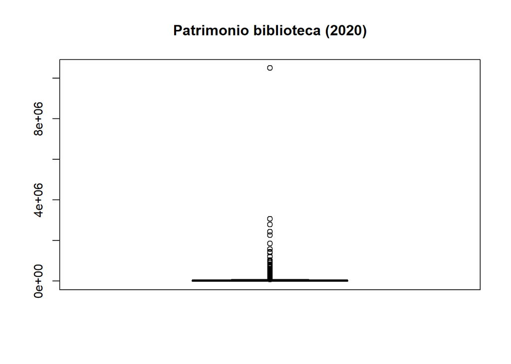

```r
boxplot(biblio$PATRIMONIO_TOT, col="skyblue3", main="Patrimonio biblioteca (2020)")
```

Vediamo difatti la presenza di diversi outlier, ma potrebbe anche trattarsi di biblioteche con un patrimonio librario molto vasto. Per avere un’idea, cerco il record corrispondente al valore più alto:

```r
biblio[which.max(biblio$PATRIMONIO_TOT),]
```

```
##     REGIONE     TIPO      FUNZIONE         MONOMULTI OPENGG UTENTIATT_TOT
## 816 Toscana Pubblica Conservazione Multidisciplinare    192         49923
##     PATRIMONIO_TOT PINT_BEF PINT_AFT PEST_BEF PEST_AFT CONSUL_BEF CONSUL_AFT
## 816       10500000      115      110       29       31          0          0
##     VOL_BEF TIRO_BEF DIGITAL_AFT PIATDIG_AFT LABO_AFT ONLINE_AFT SOCIAL_AFT
## 816      17        8          SI          SI       SI         NO         SI
##     ACCESSO_AFT PRESTITO_AFT
## 816          SI           NO
```

```r
biblio[order(biblio$PATRIMONIO_TOT, decreasing = TRUE),]
```

```
##                    REGIONE     TIPO              FUNZIONE         MONOMULTI
## 816                Toscana Pubblica         Conservazione Multidisciplinare
## 134         Emilia_Romagna  Privata Servizi_specializzati     Specialistico
## 218         Emilia_Romagna Pubblica         Conservazione Multidisciplinare
## 85                Campania Pubblica         Conservazione Multidisciplinare
## 361                  Lazio  Privata Servizi_specializzati     Specialistico
## 497              Lombardia Pubblica         Conservazione Multidisciplinare
## 319                  Lazio Pubblica         Conservazione Multidisciplinare
## 293                  Lazio Pubblica Servizi_specializzati     Specialistico
## 194         Emilia_Romagna Pubblica         Conservazione Multidisciplinare
## 140         Emilia_Romagna Pubblica      Pubblica_lettura Multidisciplinare
## 306                  Lazio Pubblica         Conservazione Multidisciplinare
## 189         Emilia_Romagna Pubblica         Conservazione Multidisciplinare
## 646               Piemonte Pubblica         Conservazione Multidisciplinare
## 722                Sicilia Pubblica      Pubblica_lettura Multidisciplinare
```

[output cut: 5885 more lines]

Tale valore risulta relativo al record 816, una biblioteca in Toscana. Facendo una rapida ricerca in rete, dal sito dell’Anagrafe delle biblioteche italiane (https://anagrafe.iccu.sbn.it/it/open-data/) ho scaricato i dati relativi al patrimonio di ciascuna biblioteca e, facendo una ricerca incrociata del valore 10500000, risulta effettivamente relativo alla Biblioteca Nazionale Centrale di Firenze, pertanto possiamo assumere che tale valore sia corretto, visto che si tratta di una delle maggiori biblioteche sia a livello nazionale che europeo.

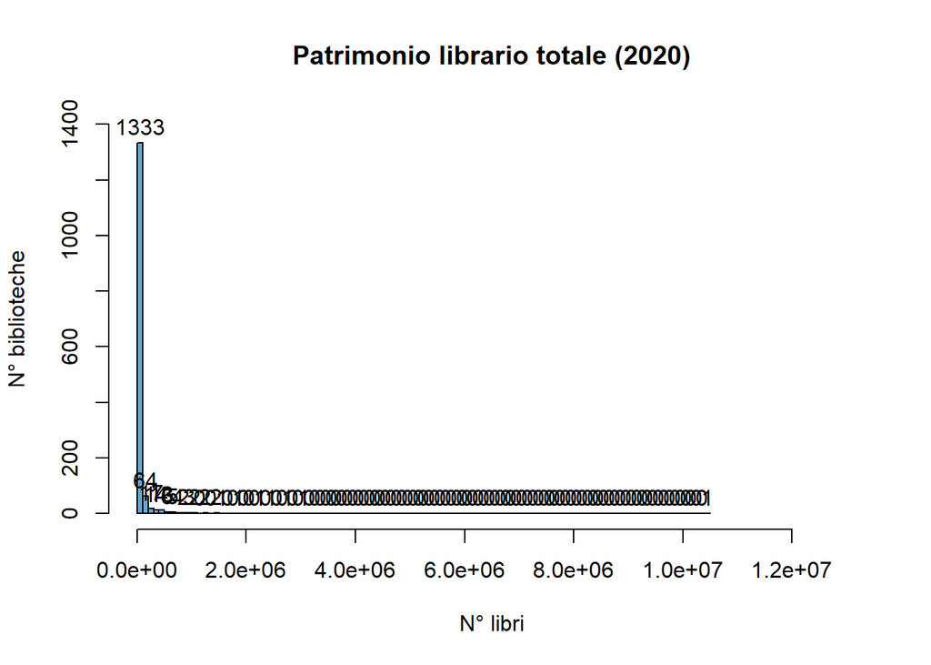

```r
istogr_patr <- hist(biblio$PATRIMONIO_TOT, main="Patrimonio librario totale (2020)",col="skyblue3",
               ylab="N° biblioteche", xlab="N° libri", breaks = 100, xlim = c(0, 13000000), ylim = c(0, 1400))

text(istogr_patr$mids,istogr_patr$counts,labels=istogr_patr$counts, adj=c(0.5, -0.5))
```

Facendo l’istogramma vediamo che, sempre a causa del valore relativo al record 816, abbiamo una visibilità ridotta sulla distribuzione dei dati. Provando ad aumentare la granularità dell’istogramma (bin = 100) iniziamo a intravedere qualcosa, ma possiamo soltanto dire che si tratta di una distribuzione fortemente leptocurtica e con asimmetria positiva.

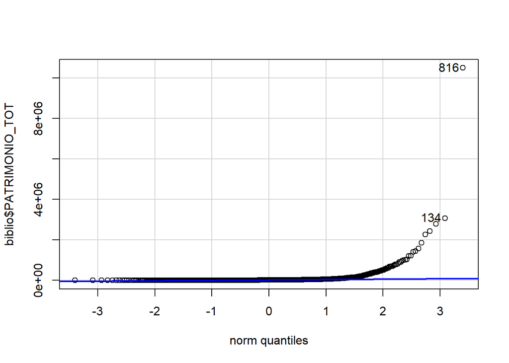

```
## [1] 816 134
```

```r
qqPlot(biblio$PATRIMONIO_TOT)
```

```r
shapiro.test(biblio$PATRIMONIO_TOT)
```

```
##
##  Shapiro-Wilk normality test
##
## data:  biblio$PATRIMONIO_TOT
## W = 0.13457, p-value < 2.2e-16
```

Dal Q-Q plot vediamo che tale distribuzione non rispecchia quella di una normale (come confermato anche dall’esito del test di Shapiro-Wilk). Inoltre, sempre dal Q-Q plot troviamo conferma dell’elevato valore associato al record 816 che in qualche modo condiziona la distribuzione.

## Variabile *OPENGG*

Dalla *summary* vediamo che le biblioteche sono rimaste aperte per circa 132 giorni, con un valore mediano molto prossimo. Ci sono biblioteche che sono state chiuse del tutto e biblioteche aperte tutto l’anno (approfondendo quest’ultimo dato, ordinando in senso decrescente il dataset per giorni di apertura, vediamo che vi sono 3 biblioteche rimaste aperte 365 giorni su 365, con un numero di utenti pari rispettivamente a 0, 2 e 6 per tutto l’anno. Viene da pensare che tali informazioni sui giorni di apertura siano da prendere con le dovute precauzioni). Considerando invece il valore opposto, vediamo che ordinando in modo crescente troviamo 2 biblioteche che non hanno aperto per niente, tuttavia se vediamo la variabile *UTENTIATT_TOT* ci accorgiamo che per queste due biblioteche ci sono stati rispettivamente 50 e 8 utenti che nell’arco del 2020 hanno usufruito di almeno un servizio della biblioteca, quindi tali valori nulli sono da considerare molto probabilmente degli errori e/o omissioni.

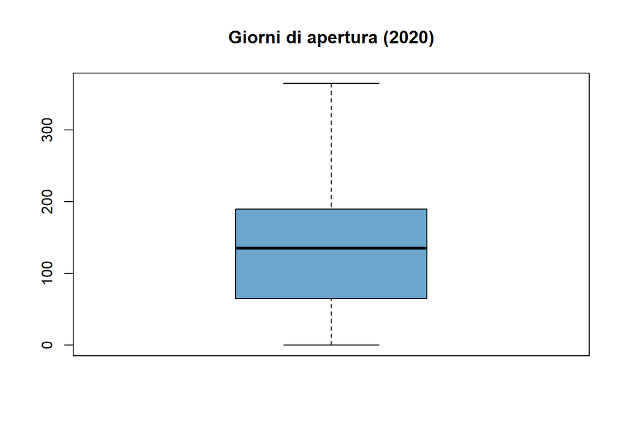

```r
boxplot(biblio$OPENGG, col="skyblue3", main="Giorni di apertura (2020)")
```

```r
biblio[order(biblio$OPENGG, decreasing = TRUE),] # ordino i gg di apertura in maniera decrescente
```

```
##                    REGIONE     TIPO              FUNZIONE         MONOMULTI
## 11                 Abruzzo Pubblica      Pubblica_lettura Multidisciplinare
## 30              Basilicata Pubblica      Pubblica_lettura Multidisciplinare
## 752                Sicilia Pubblica         Conservazione Multidisciplinare
## 539              Lombardia  Privata Servizi_specializzati     Specialistico
## 1372                Veneto Pubblica      Pubblica_lettura Multidisciplinare
## 1141                Veneto Pubblica      Pubblica_lettura Multidisciplinare
## 1077                Veneto Pubblica      Pubblica_lettura Multidisciplinare
## 243  Friuli_Venezia_Giulia  Privata Servizi_specializzati     Specialistico
## 280                  Lazio Pubblica      Pubblica_lettura Multidisciplinare
## 314                  Lazio Pubblica Servizi_specializzati     Specialistico
## 706                 Puglia  Privata Servizi_specializzati     Specialistico
## 739                Sicilia Pubblica      Pubblica_lettura Multidisciplinare
## 815                Toscana Pubblica         Conservazione Multidisciplinare
## 1065                Veneto Pubblica      Pubblica_lettura Multidisciplinare
```

[output cut: 5885 more lines]

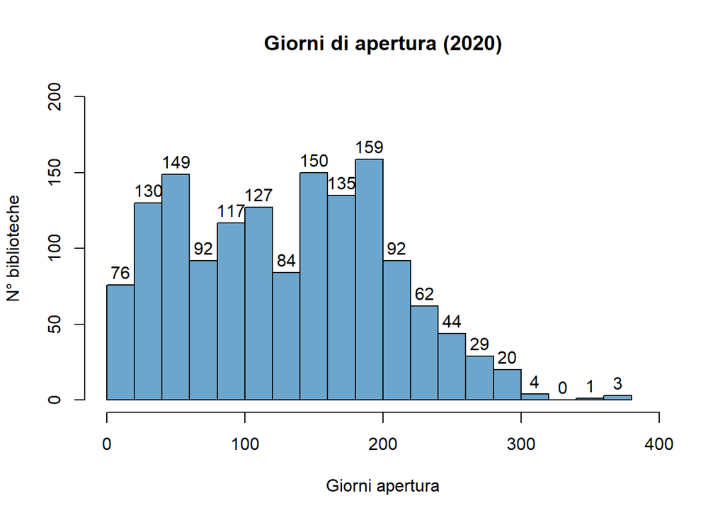

```r
istogr_gg <- hist(biblio$OPENGG, main="Giorni di apertura (2020)",col="skyblue3",
                    ylab="N° biblioteche", xlab="Giorni apertura", breaks = 25, xlim = c(0, 400), ylim = c(0, 200))
text(istogr_gg$mids,istogr_gg$counts,labels=istogr_gg$counts, adj=c(0.5, -0.5))
```

Facendo l’istogramma, inizialmente il numero di bin risulta troppo ridotto per apprezzare la distribuzione, pertanto ne ho aumentato la granularità: possiamo notare una bimodalità della distribuzione e un’asimmetria leggermente positiva. Questa leggere asimmetria potrebbe essere dovuta al fatto che durante il 2020, i giorni di chiusura sono aumentati a causa dei periodi di lockdown e dunque si ha una tendenza verso un numero minore di giorni di apertura. Tuttavia, per una conferma di quanto ipotizzato, bisognerebbe confrontare i dati del 2020 con quelli degli anni precedenti.

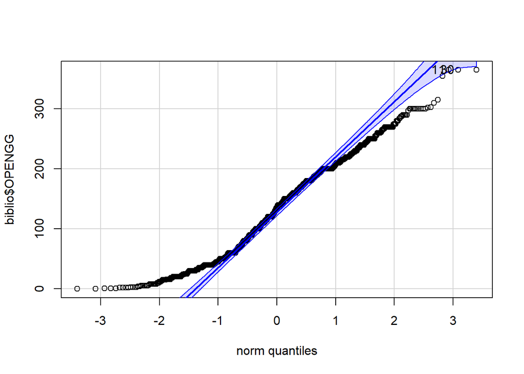

```
## [1] 11 30
```

```r
qqPlot(biblio$OPENGG)
```

Dal Q-Q plot vediamo che solo una parte della porzione centrale rispecchia una distribuzione normale, perché le code e parzialmente qualcosa verso il centro si discostano dalla normalità. Si vedono inoltre dei punti isolati che si discostano ulteriormente, tra i quali spiccano le unità statistiche 11 e 30: se andiamo a vedere tali unità ci accorgiamo che corrispondono alle biblioteche che risultano aperte 365 giorni l’anno ma con, rispettivamente, 0 e 2 utenti attivi quindi questo forte contrasto spiegherebbe la posizione estrema di tali punti.

```r
shapiro.test(biblio$OPENGG)
```

```
##
##  Shapiro-Wilk normality test
##
## data:  biblio$OPENGG
## W = 0.97488, p-value = 2.299e-15
```

Otteniamo un p-value di 2.299e-15, pertanto rigettiamo l’ipotesi di normalità (come già visto nel Q-Q plot d’altronde).

**NOTA**: si vedono in tutte le variabili, eccetto OPENGG, alti valori del coefficiente di variazione dovuti alle forti variabilità che si riscontrano in particolare nel numero di personale e nel patrimonio librario, fattori questi che sono legati alla collocazione geografica della biblioteca e che pertanto offrono una forte variabilità in tutto il territorio nazionale.

## Variabile *UTENTIATT_TOT*

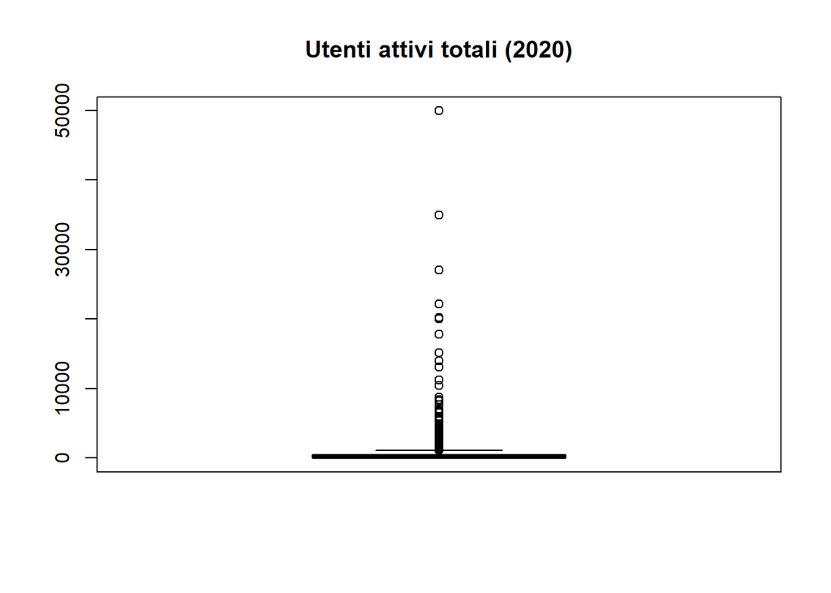

```r
boxplot(biblio$UTENTIATT_TOT, col="skyblue3", main="Utenti attivi totali (2020)")
```

Dal boxplot vediamo che anche qui ci sono diversi valori potenzialmente anomali, di cui uno in particolare che però è relativo sempre al record 816. Trattandosi, come visto, di una delle maggiori biblioteche italiane, il numero potrebbe essere coerente.

```r
biblio[which.max(biblio$UTENTIATT_TOT),] # Identificazione del record 816
```

```
##     REGIONE     TIPO      FUNZIONE         MONOMULTI OPENGG UTENTIATT_TOT
## 816 Toscana Pubblica Conservazione Multidisciplinare    192         49923
##     PATRIMONIO_TOT PINT_BEF PINT_AFT PEST_BEF PEST_AFT CONSUL_BEF CONSUL_AFT
## 816       10500000      115      110       29       31          0          0
##     VOL_BEF TIRO_BEF DIGITAL_AFT PIATDIG_AFT LABO_AFT ONLINE_AFT SOCIAL_AFT
## 816      17        8          SI          SI       SI         NO         SI
##     ACCESSO_AFT PRESTITO_AFT
## 816          SI           NO
```

Facendo l’istogramma vediamo che, sempre a causa del valore relativo al record 816, abbiamo una visibilità ridotta sulla distribuzione dei dati. Provando ad aumentare la granularità dell’istogramma (bin = 100) iniziamo a intravedere qualcosa, ma possiamo soltanto dire che si tratta di una distribuzione fortemente leptocurtica e con asimmetria positiva.

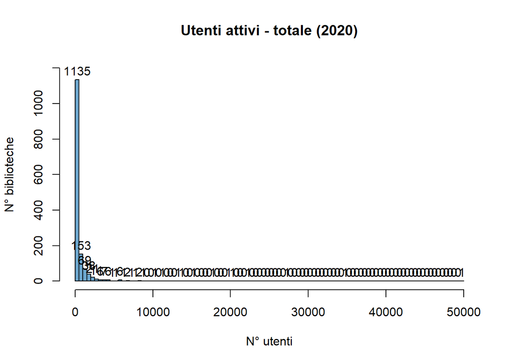

```r
istogr_utenti <- hist(biblio$UTENTIATT_TOT, main="Utenti attivi - totale (2020)",col="skyblue3",
                    ylab="N° biblioteche", xlab="N° utenti", breaks = 100, ylim = c(0, 1200))

text(istogr_utenti$mids,istogr_utenti$counts,labels=istogr_utenti$counts, adj=c(0.5, -0.5))
```

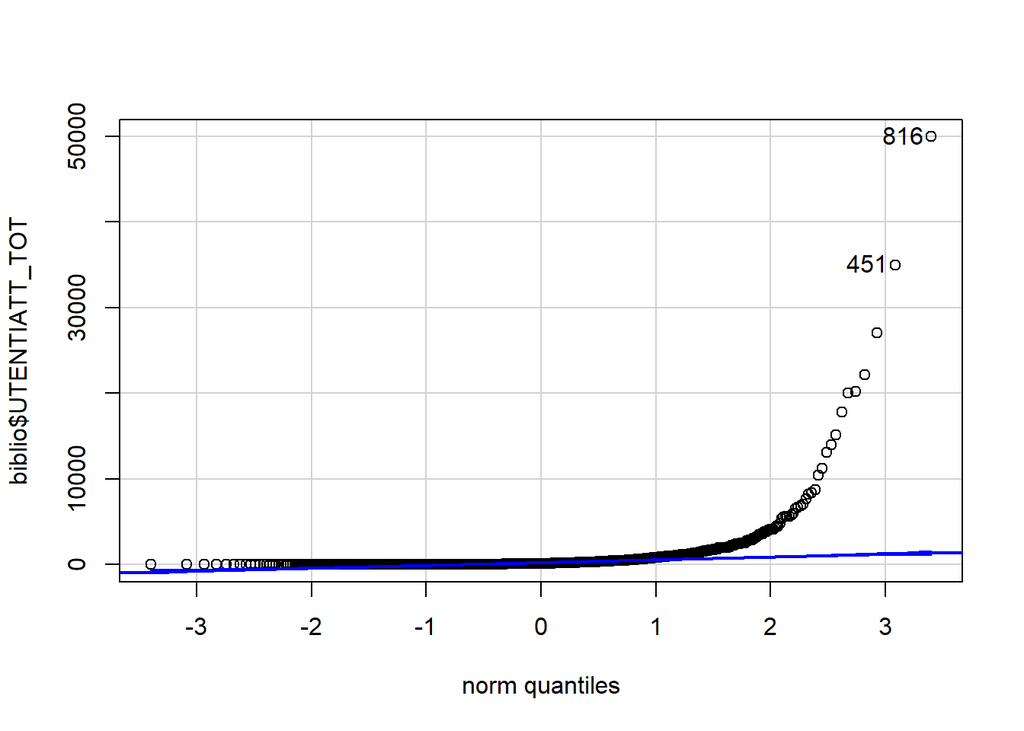

```
## [1] 816 451
```

```r
qqPlot(biblio$UTENTIATT_TOT)
```

```r
shapiro.test(biblio$UTENTIATT_TOT)
```

```
##
##  Shapiro-Wilk normality test
##
## data:  biblio$UTENTIATT_TOT
## W = 0.22139, p-value < 2.2e-16
```

Dal Q-Q plot e dal test di Shapiro-Wilk troviamo conferma della non normalità della distribuzione.

## Variabile *PINT_BEF* più altre variabili relative al personale

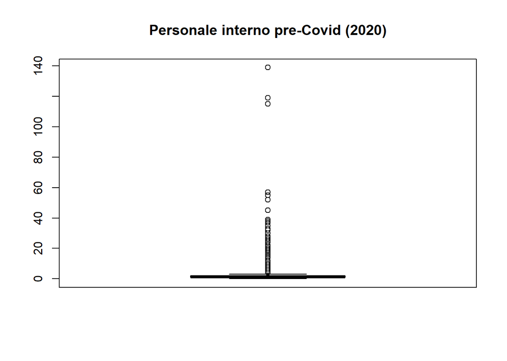

```r
boxplot(biblio$PINT_BEF, col="skyblue3", main="Personale interno pre-Covid (2020)")
```

```r
biblio[which.max(biblio$PINT_BEF),]
```

```
##     REGIONE     TIPO      FUNZIONE         MONOMULTI OPENGG UTENTIATT_TOT
## 750 Sicilia Pubblica Conservazione Multidisciplinare    155         20000
##     PATRIMONIO_TOT PINT_BEF PINT_AFT PEST_BEF PEST_AFT CONSUL_BEF CONSUL_AFT
## 750         753726      139      130        0        0          0          0
##     VOL_BEF TIRO_BEF DIGITAL_AFT PIATDIG_AFT LABO_AFT ONLINE_AFT SOCIAL_AFT
## 750       0        8          SI          SI       NO         NO         SI
##     ACCESSO_AFT PRESTITO_AFT
## 750          NO           SI
```

```r
biblio[order(biblio$PINT_BEF, decreasing = TRUE),]
```

```
##                    REGIONE     TIPO              FUNZIONE         MONOMULTI
## 750                Sicilia Pubblica         Conservazione Multidisciplinare
## 85                Campania Pubblica         Conservazione Multidisciplinare
## 816                Toscana Pubblica         Conservazione Multidisciplinare
## 646               Piemonte Pubblica         Conservazione Multidisciplinare
## 218         Emilia_Romagna Pubblica         Conservazione Multidisciplinare
## 737                Sicilia Pubblica         Conservazione Multidisciplinare
## 1429                Veneto Pubblica      Pubblica_lettura Multidisciplinare
## 301                  Lazio Pubblica Servizi_specializzati     Specialistico
## 494              Lombardia  Privata Servizi_specializzati Multidisciplinare
## 749                Sicilia Pubblica      Pubblica_lettura     Specialistico
## 428                Liguria Pubblica         Conservazione Multidisciplinare
## 1093                Veneto Pubblica Servizi_specializzati Multidisciplinare
## 239  Friuli_Venezia_Giulia Pubblica Servizi_specializzati Multidisciplinare
## 140         Emilia_Romagna Pubblica      Pubblica_lettura Multidisciplinare
```

[output cut: 5885 more lines]

```r
biblio[which(biblio$PINT_BEF == 119),]
```

```
##     REGIONE     TIPO      FUNZIONE         MONOMULTI OPENGG UTENTIATT_TOT
## 85 Campania Pubblica Conservazione Multidisciplinare    175         20230
##    PATRIMONIO_TOT PINT_BEF PINT_AFT PEST_BEF PEST_AFT CONSUL_BEF CONSUL_AFT
## 85        2429380      119      104        9        9          0          0
##    VOL_BEF TIRO_BEF DIGITAL_AFT PIATDIG_AFT LABO_AFT ONLINE_AFT SOCIAL_AFT
## 85       3        0          SI          SI       SI         SI         SI
##    ACCESSO_AFT PRESTITO_AFT
## 85          SI           NO
```

```r
biblio[which(biblio$PINT_BEF == 115),]
```

```
##     REGIONE     TIPO      FUNZIONE         MONOMULTI OPENGG UTENTIATT_TOT
## 816 Toscana Pubblica Conservazione Multidisciplinare    192         49923
##     PATRIMONIO_TOT PINT_BEF PINT_AFT PEST_BEF PEST_AFT CONSUL_BEF CONSUL_AFT
## 816       10500000      115      110       29       31          0          0
##     VOL_BEF TIRO_BEF DIGITAL_AFT PIATDIG_AFT LABO_AFT ONLINE_AFT SOCIAL_AFT
## 816      17        8          SI          SI       SI         NO         SI
##     ACCESSO_AFT PRESTITO_AFT
## 816          SI           NO
```

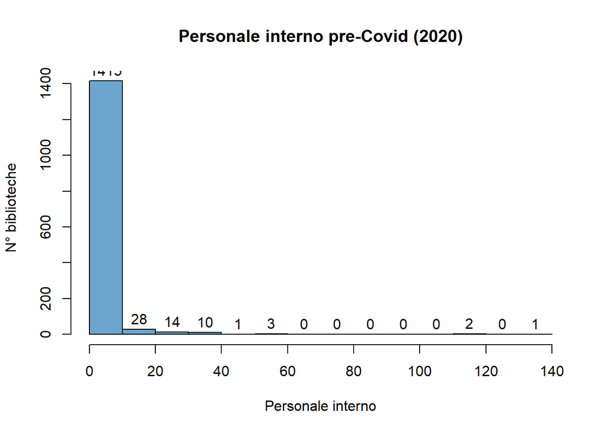

```r
istogr_pint <- hist(biblio$PINT_BEF, main="Personale interno pre-Covid (2020)",col="skyblue3",
                      ylab="N° biblioteche", xlab="Personale interno")

text(istogr_pint$mids,istogr_pint$counts,labels=istogr_pint$counts, adj=c(0.5, -0.5))
```

**NOTA**: dai numeri presenti per le variabili relative al personale possiamo dire di non avere outliers in quanto valori plausibili. I boxplot li usiamo rapidamente per verificare che non vi siano valori troppo estremi, ma fatto ciò per l’esplorazione di tali variabili useremo dei bar plot affiancati.

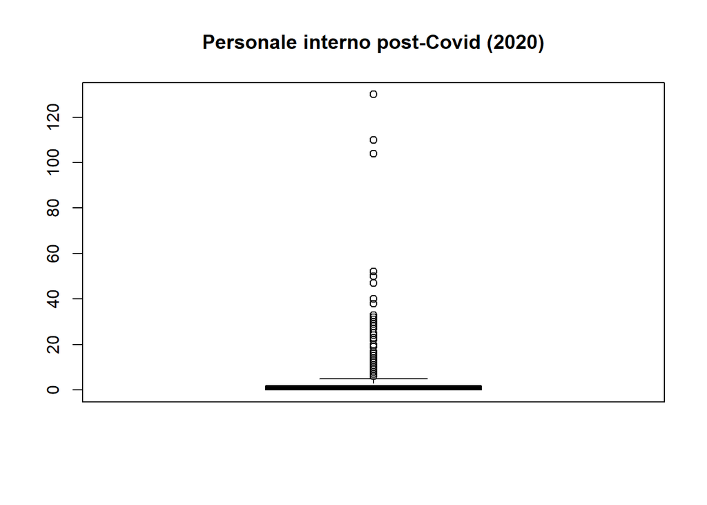

```r
boxplot(biblio$PINT_AFT, col="skyblue3", main="Personale interno post-Covid (2020)")
```

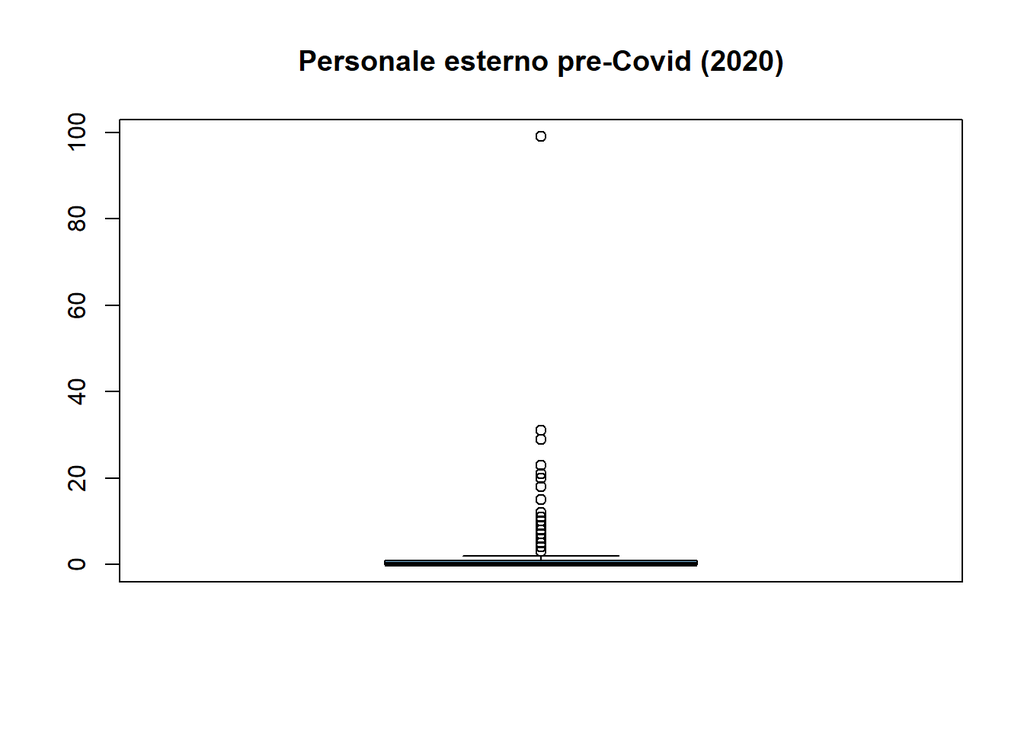

```r
boxplot(biblio$PEST_BEF, col="skyblue3", main="Personale esterno pre-Covid (2020)")
```

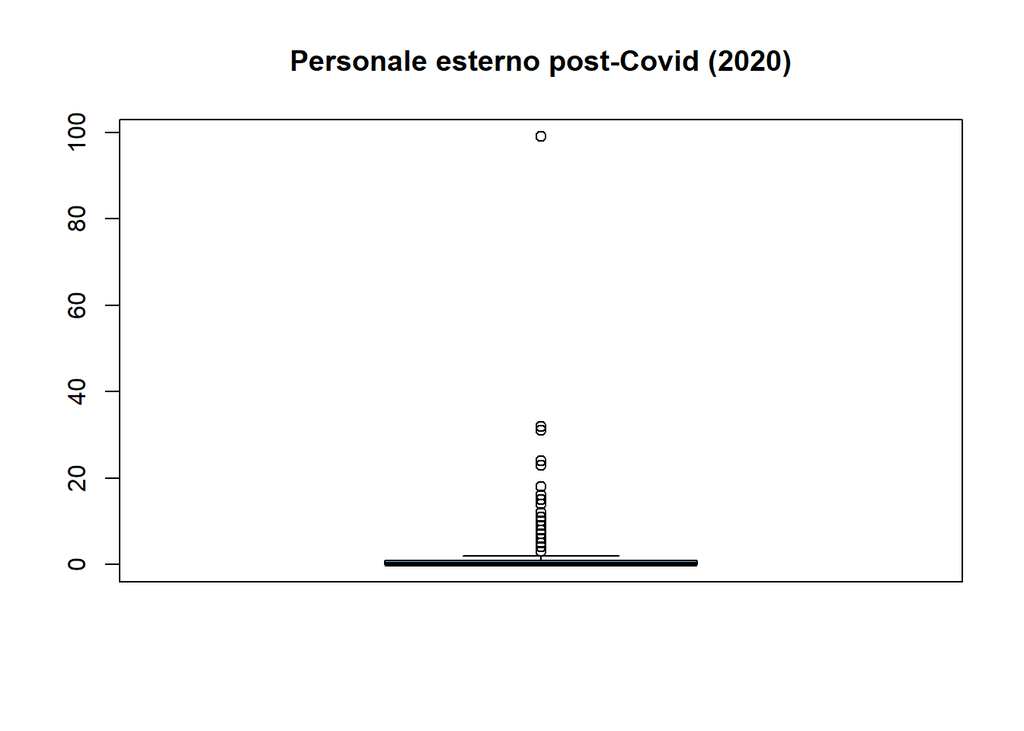

```r
boxplot(biblio$PEST_AFT, col="skyblue3", main="Personale esterno post-Covid (2020)")
```

Per ottenere i bar plot affiancati, faccio le seguenti operazioni preliminari:

```r
# interno
total_pint_bef <- sum(biblio$PINT_BEF)
total_pint_bef
```

```
## [1] 3927
```

```r
total_pint_aft <- sum(biblio$PINT_AFT)
total_pint_aft
```

```
## [1] 3607
```

```r
# esterno
total_pest_bef <- sum(biblio$PEST_BEF)
total_pest_bef
```

```
## [1] 1076
```

```r
total_pest_aft <- sum(biblio$PEST_AFT)
total_pest_aft
```

```
## [1] 1047
```

```r
# consulenti
total_con_bef <- sum(biblio$CONSUL_BEF)
total_con_bef
```

```
## [1] 547
```

```r
total_con_aft <- sum(biblio$CONSUL_AFT)
total_con_aft
```

```
## [1] 510
```

**NOTA**: per i volontari non lo facciamo perché ci manca il dato relativo al post, idem per gli stagisti

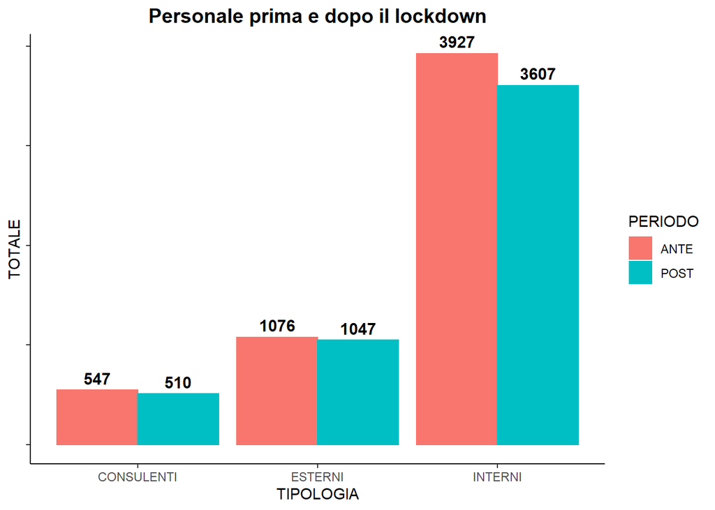

```r
total.df <- data.frame("ANTE", "INTERNI", total_pint_bef)
names(total.df) <- c("PERIODO", "TIPOLOGIA", "TOTALE")
total.df[nrow(total.df) + 1,] <- c("POST", "INTERNI", total_pint_aft)
total.df[nrow(total.df) + 1,] <- c("ANTE", "ESTERNI", total_pest_bef)
total.df[nrow(total.df) + 1,] <- c("POST", "ESTERNI", total_pest_aft)
total.df[nrow(total.df) + 1,] <- c("ANTE", "CONSULENTI", total_con_bef)
total.df[nrow(total.df) + 1,] <- c("POST", "CONSULENTI", total_con_aft)

total.df$TOTALE <- as.numeric(total.df$TOTALE)

ggplot(total.df, aes(x = TIPOLOGIA, y = TOTALE, fill = PERIODO, colour = PERIODO)) +
  geom_bar(stat = "identity", position = "dodge") +
  geom_text(aes(label=TOTALE), fontface = "bold", colour = "black", vjust = -0.5, position = position_dodge(.9), size = 4) +
  theme_bw() + theme(panel.border = element_blank(), panel.grid.major = element_blank(),
                     panel.grid.minor = element_blank(), axis.line = element_line(colour = "black")) +
  theme(plot.title = element_text(color="black", size=14, face="bold", hjust = 0.5), axis.text.y=element_blank()) +
  ggtitle("Personale prima e dopo il lockdown")
```

Dai bar plot affiancati, possiamo vedere come il numero del personale è stato ridotto dal periodo pre-lockdown al dicembre 2020 (indicato sinteticamente come post), come d’altronde era da aspettarsi. Volendo calcolare la riduzione percentuale per le varie tipologie di personale:

```r
perc.int <- (total_pint_aft - total_pint_bef)/total_pint_bef*100
perc.est <- (total_pest_aft - total_pest_bef)/total_pest_bef*100
perc.con <- (total_con_aft - total_con_bef)/total_con_bef*100
```

Abbiamo quindi che tra il periodo antecedente al primo lockdown e la fine del 2020, c’è stata una riduzione pari a -8.15% per il personale interno, una riduzione del -2.7% per il personale esterno ed una riduzione del -6.76% per i consulenti.

Passiamo ora alle variabili qualitative:

## Variabile *REGIONE*

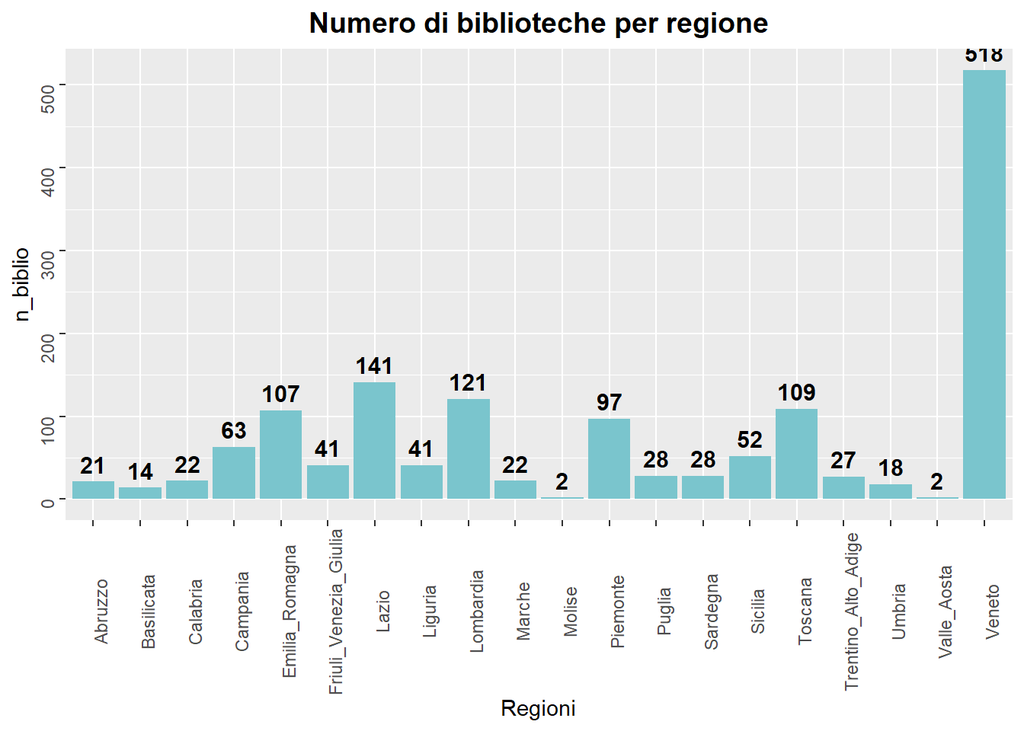

```r
# REGIONE
count.reg <- summary(biblio$REGIONE)
df.reg <- as.data.frame(count.reg)
df.reg$Regioni <- row.names(df.reg)
colnames(df.reg)[1] <- "n_biblio"

ggplot(df.reg, aes(x = Regioni, y = n_biblio)) + geom_bar(stat = "identity", fill = "cadetblue3") +
  theme(plot.title = element_text(color="black", size=14, face="bold", hjust = 0.5), axis.text = element_text(angle = 90)) +
  geom_text(aes(label=n_biblio), fontface = "bold", colour = "black", vjust = -0.5, position = position_dodge(.9), size = 4) +
  ggtitle("Numero di biblioteche per regione")
```

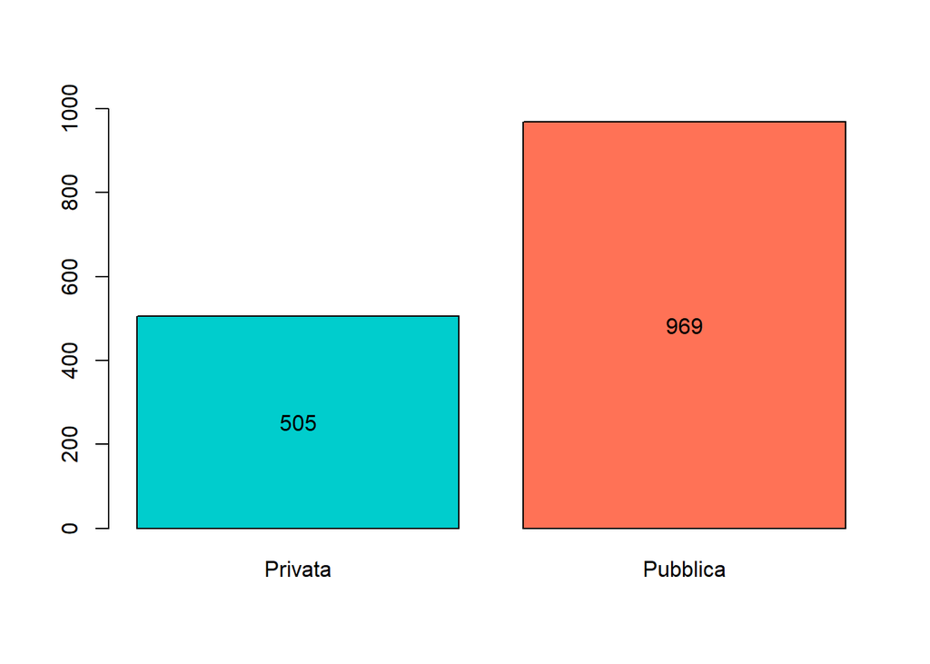

```r
# TIPO
tab <- table(biblio$TIPO)
b <- barplot(tab, col = c("cyan3", "coral1"), ylim = c(0, 1000))
text(x=b, y=tab/2, labels=tab)
```

Per quanto riguarda le regioni, vediamo che la regione con il più alto numero di biblioteche, relative al nostro dataset, è il Veneto. A una rapida occhiata, il numero di biblioteche sembra in qualche modo proporzionato alla dimensione della regione e/o al numero di abitanti (per un controllo più preciso bisognerebbe incrociare altri dati). Delle 1474 biblioteche presenti nel nostro dataset, 505 sono private e 969 sono pubbliche.

# Principal component analysis - PCA

Avendo già effettuato un minimo di analisi esplorativa sulle singole variabili, possiamo procedere verso la PCA. Innanzitutto, visto che utilizzeremo come variabili attive le variabili dalla 5 alla 15, e le variabili dalla 1 alla 4 come variabili illustrative qualitative, creiamo un sottoinsieme del dataset di partenza che le contiene e su cui effettueremo la PCA:

```r
biblio.rid <- biblio[, 1:15]
biblio.rid
```

```
##                    REGIONE     TIPO              FUNZIONE         MONOMULTI
## 1                  Abruzzo Pubblica      Pubblica_lettura Multidisciplinare
## 2                  Abruzzo Pubblica         Conservazione Multidisciplinare
## 3                  Abruzzo  Privata Servizi_specializzati     Specialistico
## 4                  Abruzzo Pubblica      Pubblica_lettura Multidisciplinare
## 5                  Abruzzo  Privata         Conservazione     Specialistico
## 6                  Abruzzo  Privata Servizi_specializzati     Specialistico
## 7                  Abruzzo  Privata Servizi_specializzati Multidisciplinare
## 8                  Abruzzo Pubblica         Conservazione     Specialistico
## 9                  Abruzzo Pubblica      Pubblica_lettura Multidisciplinare
## 10                 Abruzzo Pubblica      Pubblica_lettura Multidisciplinare
## 11                 Abruzzo Pubblica      Pubblica_lettura Multidisciplinare
## 12                 Abruzzo Pubblica Servizi_specializzati     Specialistico
## 13                 Abruzzo  Privata Servizi_specializzati     Specialistico
## 14                 Abruzzo Pubblica Servizi_specializzati     Specialistico
```

[output cut: 4410 more lines]

**NOTA**: siccome le variabili quantitative in esame hanno differenti unità di misura, è buona regola effettuare una standardizzazione, che nel nostro caso viene effettuata di default dalla funzione PCA di *FactoMineR*.

```r
biblio.pca <- PCA(biblio.rid, quali.sup = 1:4, graph = F)
```

Scegliamo innanzitutto le componenti principali, andando a vedere sia gli autovalori che la percentuale di inerzia associata a ciascuna componente principale:

```r
biblio.pca$eig
```

```
##          eigenvalue percentage of variance cumulative percentage of variance
## comp 1  3.988326439            36.25751308                          36.25751
## comp 2  1.766181504            16.05619550                          52.31371
## comp 3  1.433913103            13.03557367                          65.34928
## comp 4  1.017731988             9.25210898                          74.60139
## comp 5  0.947212621             8.61102383                          83.21242
## comp 6  0.780931662             7.09937875                          90.31179
## comp 7  0.505996517             4.59996834                          94.91176
## comp 8  0.307848852             2.79862593                          97.71039
## comp 9  0.227644413             2.06949466                          99.77988
## comp 10 0.017631542             0.16028675                          99.94017
## comp 11 0.006581358             0.05983053                         100.00000
```

```r
summary(biblio.pca)
```

```
##
## Call:
## PCA(X = biblio.rid, quali.sup = 1:4, graph = F)
##
##
## Eigenvalues
##                        Dim.1   Dim.2   Dim.3   Dim.4   Dim.5   Dim.6   Dim.7
## Variance               3.988   1.766   1.434   1.018   0.947   0.781   0.506
## % of var.             36.258  16.056  13.036   9.252   8.611   7.099   4.600
## Cumulative % of var.  36.258  52.314  65.349  74.601  83.212  90.312  94.912
##                        Dim.8   Dim.9  Dim.10  Dim.11
## Variance               0.308   0.228   0.018   0.007
## % of var.              2.799   2.069   0.160   0.060
## Cumulative % of var.  97.710  99.780  99.940 100.000
##
## Individuals (the 10 first)
##                           Dist    Dim.1    ctr   cos2    Dim.2    ctr   cos2
## 1                     |  1.707 | -0.932  0.015  0.298 | -0.187  0.001  0.012 |
## 2                     |  1.734 |  1.012  0.017  0.340 | -0.692  0.018  0.159 |
## 3                     |  2.401 | -0.020  0.000  0.000 |  0.971  0.036  0.164 |
## 4                     |  0.935 | -0.664  0.007  0.504 | -0.260  0.003  0.078 |
## 5                     |  1.450 | -0.071  0.000  0.002 |  0.988  0.037  0.464 |
## 6                     |  1.583 | -0.889  0.013  0.315 | -0.174  0.001  0.012 |
## 7                     |  5.547 | -0.439  0.003  0.006 |  0.264  0.003  0.002 |
## 8                     |  2.190 | -0.471  0.004  0.046 | -0.499  0.010  0.052 |
## 9                     |  1.107 | -0.625  0.007  0.318 | -0.138  0.001  0.016 |
## 10                    |  1.645 | -0.783  0.010  0.226 | -0.125  0.001  0.006 |
##                        Dim.3    ctr   cos2
## 1                      0.043  0.000  0.001 |
## 2                     -0.504  0.012  0.084 |
## 3                      0.182  0.002  0.006 |
## 4                      0.029  0.000  0.001 |
## 5                      0.332  0.005  0.053 |
## 6                      0.088  0.000  0.003 |
## 7                      1.300  0.080  0.055 |
## 8                     -0.447  0.009  0.042 |
## 9                     -0.383  0.007  0.120 |
## 10                     0.231  0.003  0.020 |
##
## Variables (the 10 first)
```

[output cut: 31 more lines]

```
## Lazio                 |  0.463 |  0.103  0.049  0.642 |  0.077  0.028  0.724 |
## Liguria               |  0.642 | -0.390  0.370 -1.269 | -0.199  0.096 -0.970 |
## Lombardia             |  0.406 |  0.220  0.294  1.267 |  0.116  0.081  1.002 |
## Marche                |  0.538 | -0.323  0.361 -0.764 |  0.250  0.215  0.887 |
##                        Dim.3   cos2 v.test
## Abruzzo                0.068  0.011  0.262 |
## Basilicata             0.084  0.011  0.264 |
## Calabria               0.240  0.057  0.945 |
## Campania               0.447  0.258  3.030 |
## Emilia_Romagna         0.091  0.117  0.818 |
## Friuli_Venezia_Giulia  0.127  0.152  0.691 |
## Lazio                  0.099  0.046  1.031 |
## Liguria                0.016  0.001  0.088 |
## Lombardia             -0.010  0.001 -0.092 |
## Marche                -0.014  0.001 -0.054 |
```

Dall’analisi degli autovalori abbiamo 4 autovalori > 1, quindi potremmo pensare di scegliere quattro componenti principali. Difatti, andando a vedere la percentuale di varianza spiegata associata a ciascuna componente, vediamo che utilizzando 4 componenti principali abbiamo un’inerzia totale di circa il 75%, mentre se ci fermassimo a due componenti avremmo un’inerzia totale soltanto del 52%. Optiamo quindi per la scelta di 4 componenti principali. Bisogna aggiungere che non c’è una grande percentuale di inerzia portata dalle varie componenti principali e soprattutto non c’è una componente principale predominante sulle altre: vuol dire quindi che anche guardando la prima componente non ci sarà una spiegazione così evidente della varianza del fenomeno latente nel dataset.

Nuvola degli individui:

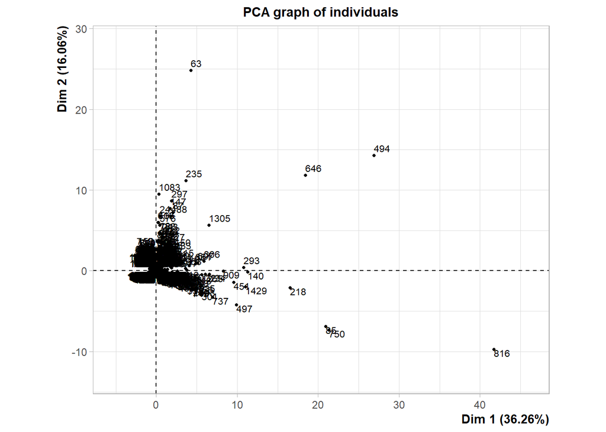

```r
plot.PCA(biblio.pca, invisible = c("var", "quali"), cex=0.7, axes = 1:2) # 1° e 2° componente principale
```

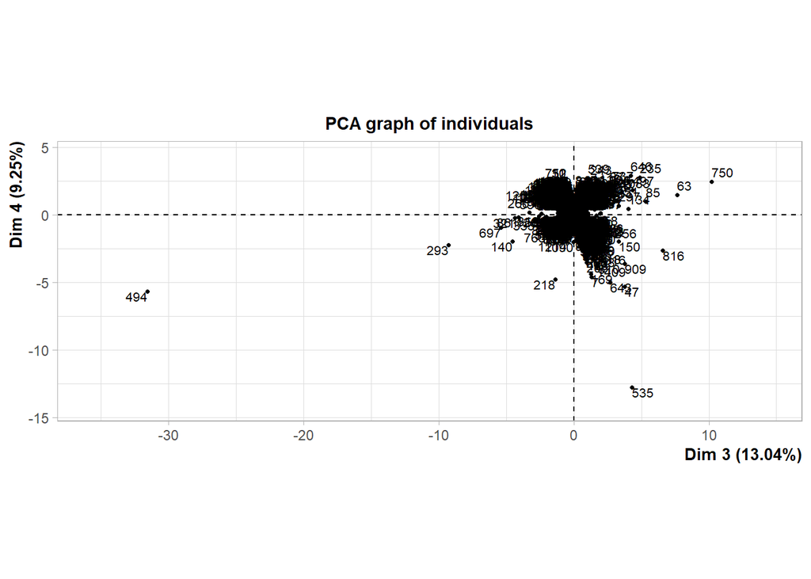

```r
plot.PCA(biblio.pca, invisible = c("var", "quali"), cex=0.7, axes = 3:4) # 3° e 4° componente principale
```

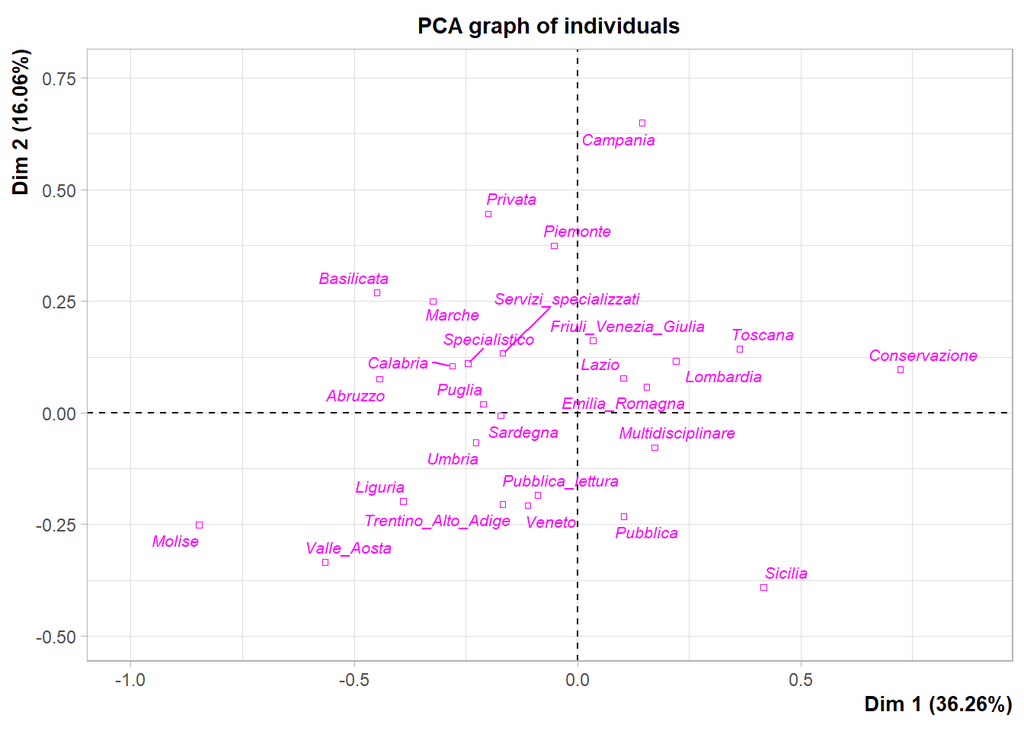

```r
plot.PCA(biblio.pca, invisible = c("var", "ind"), cex=0.7, axes = 1:2) # visualizzo le sole variabili supplementari
```

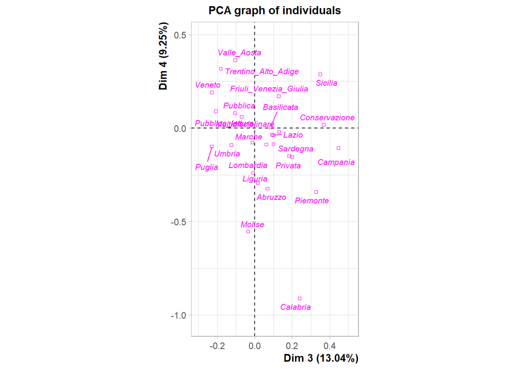

```r
plot.PCA(biblio.pca, invisible = c("var", "ind"), cex=0.7, axes = 3:4) # visualizzo le sole variabili supplementari
```

Cerchio delle correlazioni:

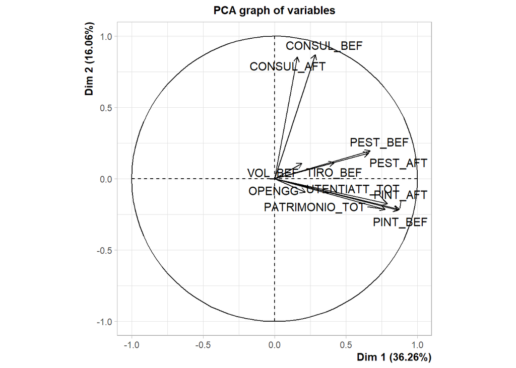

```r
plot(biblio.pca, choix = "var", axes = 1:2) # 1° e 2° componente principale
```

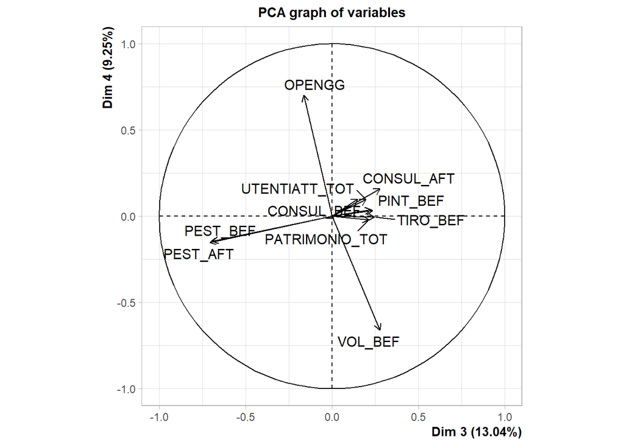

```r
plot(biblio.pca, choix = "var", axes = 3:4) # 3° e 4° componente principale
```

Studiamo ora i contributi contenuti nell’oggetto *biblio.pca*:

```r
biblio.pca$var$coord
```

```
##                    Dim.1       Dim.2      Dim.3        Dim.4       Dim.5
## OPENGG         0.2164746 -0.09459806 -0.1628329  0.700600074  0.56191885
## UTENTIATT_TOT  0.7908512 -0.17387415  0.1976631  0.095922251 -0.06529474
## PATRIMONIO_TOT 0.7748097 -0.21393515  0.2121652 -0.020286575 -0.10051769
## PINT_BEF       0.8672783 -0.21909687  0.2349508  0.033451077 -0.16772629
## PINT_AFT       0.8744733 -0.21547217  0.2255776  0.036517289 -0.16404355
## PEST_BEF       0.6696499  0.19546256 -0.6935503 -0.145925860  0.01793491
## PEST_AFT       0.6579315  0.17950608 -0.7063519 -0.152498965  0.01585225
## CONSUL_BEF     0.2842463  0.87123529  0.1494920  0.098909413 -0.07852445
## CONSUL_AFT     0.1603043  0.85588739  0.2785824  0.158663732 -0.12313642
## VOL_BEF        0.1916047  0.10877122  0.2781432 -0.659772438  0.52024274
## TIRO_BEF       0.4174970  0.11378562  0.2448713 -0.004381839  0.51913013
```

A conferma di quanto visto nel cerchio delle correlazioni, possiamo vedere come la prima componente principale sia fortemente correlata alle variabili *PINT_BEF/AFT*, *UTENTIATT*, *PATRIMONIO*, *PEST_BEF/AFT*; la seconda componente alle variabili *CONSUL_BEF/AFT*, la terza è correlata negativamente alle variabili *PEST_BEF/AFT*. La quarta è correlata a *OPENGG* e negativamente a *VOL_BEF*.

```r
biblio.pca$var$contrib
```

```
##                     Dim.1      Dim.2     Dim.3        Dim.4       Dim.5
## OPENGG          1.1749598  0.5066746  1.849105 48.228852941 33.33494328
## UTENTIATT_TOT  15.6819065  1.7117278  2.724761  0.904076750  0.45009991
## PATRIMONIO_TOT 15.0521811  2.5913673  3.139248  0.040437476  1.06668827
## PINT_BEF       18.8593289  2.7179221  3.849736  0.109947863  2.96998886
## PINT_AFT       19.1735426  2.6287363  3.548700  0.131027853  2.84099753
## PEST_BEF       11.2435872  2.1631760 33.545411  2.092334420  0.03395870
## PEST_AFT       10.8535215  1.8244123 34.795201  2.285074530  0.02652984
## CONSUL_BEF      2.0258113 42.9769493  1.558522  0.961262107  0.65097204
## CONSUL_AFT      0.6443173 41.4761012  5.412335  2.473556919  1.60075770
## VOL_BEF         0.9204949  0.6698733  5.395281 42.771542543 28.57357464
## TIRO_BEF        4.3703489  0.7330599  4.181701  0.001886598 28.45148923
```

```r
biblio.pca$var$cos2
```

```
##                     Dim.1       Dim.2      Dim.3        Dim.4        Dim.5
## OPENGG         0.04686123 0.008948794 0.02651457 4.908405e-01 0.3157527899
## UTENTIATT_TOT  0.62544562 0.030232219 0.03907071 9.201078e-03 0.0042634032
## PATRIMONIO_TOT 0.60033012 0.045768250 0.04501408 4.115451e-04 0.0101038059
## PINT_BEF       0.75217160 0.048003437 0.05520187 1.118975e-03 0.0281321093
## PINT_AFT       0.76470347 0.046428255 0.05088527 1.333512e-03 0.0269102872
## PEST_BEF       0.44843096 0.038205614 0.48101204 2.129436e-02 0.0003216611
## PEST_AFT       0.43287387 0.032222432 0.49893294 2.325593e-02 0.0002512940
## CONSUL_BEF     0.08079597 0.759050930 0.02234785 9.783072e-03 0.0061660893
## CONSUL_AFT     0.02569748 0.732543229 0.07760818 2.517418e-02 0.0151625790
## VOL_BEF        0.03671234 0.011831178 0.07736364 4.352997e-01 0.2706525052
## TIRO_BEF       0.17430378 0.012947168 0.05996196 1.920051e-05 0.2694960968
```

**NOTA**: cercando su internet maggiori informazioni relative alla categoria di personale esterno, ho trovato che tale categoria potrebbe comprendere, per esclusione, i soggetti che fanno servizio civile e gli studenti borsisti. Come si evince dalla tabella, riportata nel sito *https://www.aib.it/struttura/osservatorio-lavoro-e-professione/2013/34839-linee-indirizzo-personale-supporto-ai-bibliotecari/* , queste sono le uniche due categorie relative al personale esterno che prevedono un compenso. Tuttavia, se guardiamo la seconda componente, le variabili che contribuiscono maggiormente sono le due relative ai consulenti, che sono anche loro figure che prevedono un compenso. Evidentemente la distinzione riguarderà il fatto che il personale esterno, così come i borsisti e le persone del servizio civile sono in qualche modo vincolate da contratti pubblici di somministrazione, mentre i consulenti saranno professionisti provenienti da società private e dunque soggetti a condizioni differenti di reclutamento e differenti mansioni.

```r
biblio[235,]
```

```
##                   REGIONE    TIPO              FUNZIONE     MONOMULTI OPENGG
## 235 Friuli_Venezia_Giulia Privata Servizi_specializzati Specialistico    160
##     UTENTIATT_TOT PATRIMONIO_TOT PINT_BEF PINT_AFT PEST_BEF PEST_AFT CONSUL_BEF
## 235          2400          88000        3        3        0        0         11
##     CONSUL_AFT VOL_BEF TIRO_BEF DIGITAL_AFT PIATDIG_AFT LABO_AFT ONLINE_AFT
## 235         11       0        9          SI          SI       SI         SI
##     SOCIAL_AFT ACCESSO_AFT PRESTITO_AFT
## 235         SI          SI           SI
```

```r
biblio[1083,]
```

```
##      REGIONE     TIPO         FUNZIONE         MONOMULTI OPENGG UTENTIATT_TOT
## 1083  Veneto Pubblica Pubblica_lettura Multidisciplinare     32            60
##      PATRIMONIO_TOT PINT_BEF PINT_AFT PEST_BEF PEST_AFT CONSUL_BEF CONSUL_AFT
## 1083           4400        1        0        0        0          0         18
##      VOL_BEF TIRO_BEF DIGITAL_AFT PIATDIG_AFT LABO_AFT ONLINE_AFT SOCIAL_AFT
## 1083       0        0          SI          SI       NO         NO         NO
##      ACCESSO_AFT PRESTITO_AFT
## 1083          SI           SI
```

```r
biblio[494,]
```

```
##       REGIONE    TIPO              FUNZIONE         MONOMULTI OPENGG
## 494 Lombardia Privata Servizi_specializzati Multidisciplinare    245
##     UTENTIATT_TOT PATRIMONIO_TOT PINT_BEF PINT_AFT PEST_BEF PEST_AFT CONSUL_BEF
## 494          6000          70000       38       38       99       99         13
##     CONSUL_AFT VOL_BEF TIRO_BEF DIGITAL_AFT PIATDIG_AFT LABO_AFT ONLINE_AFT
## 494          4       0        0          SI          SI       SI         SI
##     SOCIAL_AFT ACCESSO_AFT PRESTITO_AFT
## 494         NO          SI           SI
```

```r
biblio[816,]
```

```
##     REGIONE     TIPO      FUNZIONE         MONOMULTI OPENGG UTENTIATT_TOT
## 816 Toscana Pubblica Conservazione Multidisciplinare    192         49923
##     PATRIMONIO_TOT PINT_BEF PINT_AFT PEST_BEF PEST_AFT CONSUL_BEF CONSUL_AFT
## 816       10500000      115      110       29       31          0          0
##     VOL_BEF TIRO_BEF DIGITAL_AFT PIATDIG_AFT LABO_AFT ONLINE_AFT SOCIAL_AFT
## 816      17        8          SI          SI       SI         NO         SI
##     ACCESSO_AFT PRESTITO_AFT
## 816          SI           NO
```

Naturalmente, visto che tale componente spiega circa il 36% della variabilità totale, avremo alcuni individui che pur trovandosi più a destra di altri, avranno un rapporto utenti/giorni inferiore, ma in linea di massima il trend è questo.

Guardando le variabili illustrative qualitative vediamo che le biblioteche pubbliche si collocano perlopiù nella parte in basso a destra del piano, mentre quelle private in alto a sinistra: possiamo quindi supporre che nelle biblioteche pubbliche vi sia un maggior numero di dipendenti interni/esterni mentre in quelle private un maggior numero di consulenti. Inoltre, le biblioteche private sono quelle relative ai servizi specializzati, le quali si trovano nella maggior parte dei casi al Centro-Sud. Vediamo invece che le biblioteche che offrono servizi di pubblica lettura e conservazione sono collocate perlopiù al Centro-Nord.

Riprendendo i comandi per visualizzare la nuvola di individui e il cerchio delle correlazioni per la terza e la quarta componente principale:

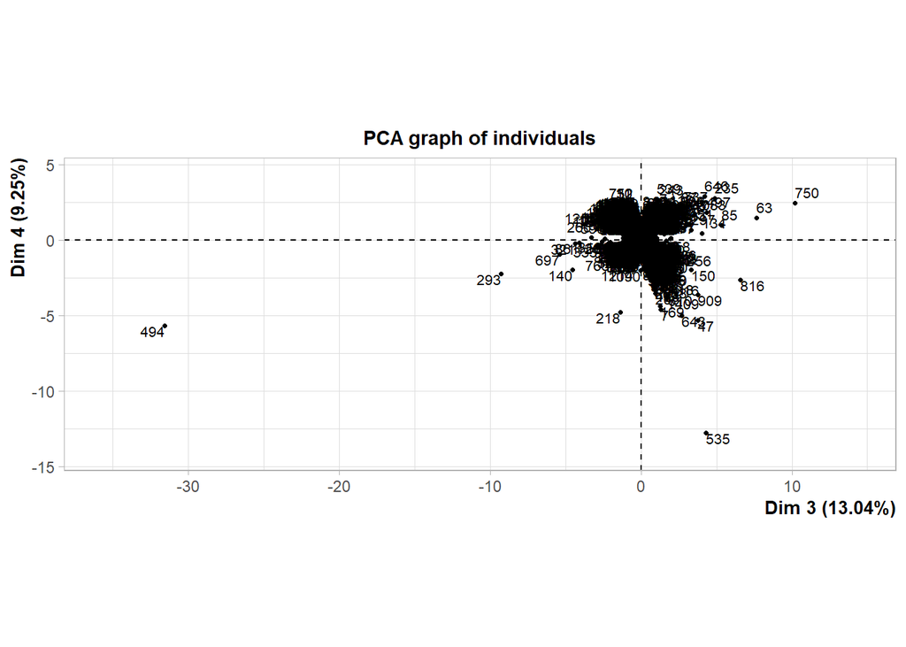

```r
plot.PCA(biblio.pca, invisible = c("var", "quali"), cex=0.7, axes = 3:4) # 3° e 4° componente principale
```

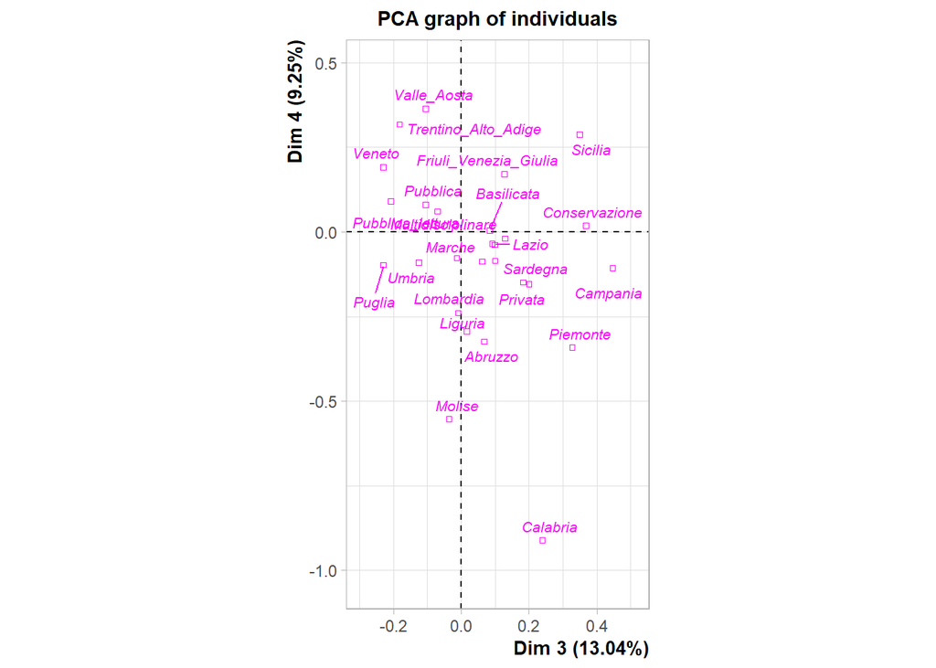

```r
plot.PCA(biblio.pca, invisible = c("var", "ind"), cex=0.7, axes = 3:4) # visualizzo le sole variabili supplementari
```

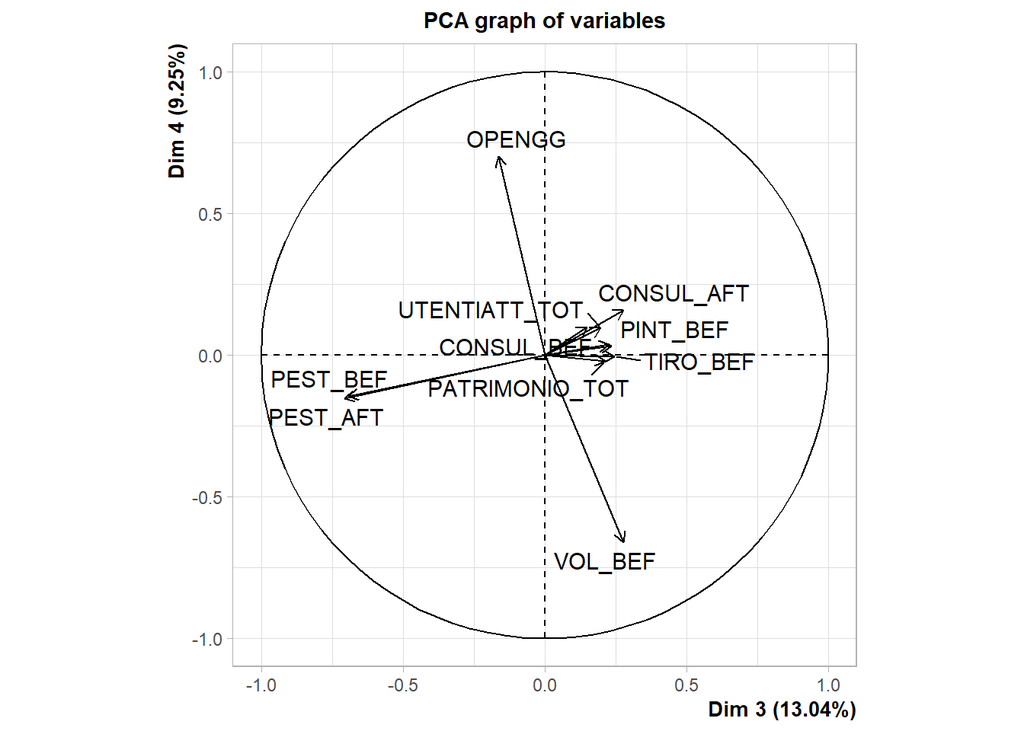

```r
plot(biblio.pca, choix = "var", axes = 3:4) # 3° e 4° componente principale
```

**Analisi della 3° componente principale**: le variabili più fortemente correlate, stavolta negativamente, alla terza componente principale (sia dall’ispezione visiva del cerchio delle correlazioni, che dall’analisi dei contributi) risultano essere *PEST_BEF/AFT*. Se consideriamo il rapporto personale esterno/personale interno vediamo difatti che, andando da sinistra verso destra lungo la terza componente, abbiamo man mano una diminuzione di questo rapporto: ad es. considerando l’individuo 494 sull’estrema sinistra abbiamo un valore di circa 2.6, mentre se prendiamo gli individui 697 e 218 abbiamo rispettivamente 1.63 e 0.48, fino ad arrivare ai quadranti 1-3 in cui abbiamo gli individui 63, 535 e 750 con 0 personale esterno. Guardando le variabili supplementari qualitative, fondamentalmente possiamo dire che la terza componente è relativa alla tipologia di biblioteca: difatti spaziamo dalla biblioteca pubblica in cui si effettua la pubblica lettura (sinistra) fino alla biblioteca privata in cui si effettua sostanzialmente conservazione (sulla destra), passando per i vari servizi offerti. Se incrociamo quest’ultima informazione derivante dall’analisi delle variabili supplementari con quanto visto dalle variabili attive, possiamo vedere infatti come nelle biblioteche pubbliche con funzioni di pubblica consultazione, si ricorra maggiormente a personale esterno rispetto a quelle private, con funzione di conservazione.

```r
biblio[494,]
```

```
##       REGIONE    TIPO              FUNZIONE         MONOMULTI OPENGG
## 494 Lombardia Privata Servizi_specializzati Multidisciplinare    245
##     UTENTIATT_TOT PATRIMONIO_TOT PINT_BEF PINT_AFT PEST_BEF PEST_AFT CONSUL_BEF
## 494          6000          70000       38       38       99       99         13
##     CONSUL_AFT VOL_BEF TIRO_BEF DIGITAL_AFT PIATDIG_AFT LABO_AFT ONLINE_AFT
## 494          4       0        0          SI          SI       SI         SI
##     SOCIAL_AFT ACCESSO_AFT PRESTITO_AFT
## 494         NO          SI           SI
```

```r
biblio[697,]
```

```
##     REGIONE     TIPO              FUNZIONE     MONOMULTI OPENGG UTENTIATT_TOT
## 697  Puglia Pubblica Servizi_specializzati Specialistico    175           364
##     PATRIMONIO_TOT PINT_BEF PINT_AFT PEST_BEF PEST_AFT CONSUL_BEF CONSUL_AFT
## 697          46724       11       11       18       18          0          0
##     VOL_BEF TIRO_BEF DIGITAL_AFT PIATDIG_AFT LABO_AFT ONLINE_AFT SOCIAL_AFT
## 697       0        4          SI          NO       NO         SI         SI
##     ACCESSO_AFT PRESTITO_AFT
## 697          SI           NO
```

```r
biblio[218,]
```

```
##            REGIONE     TIPO      FUNZIONE         MONOMULTI OPENGG
## 218 Emilia_Romagna Pubblica Conservazione Multidisciplinare    246
##     UTENTIATT_TOT PATRIMONIO_TOT PINT_BEF PINT_AFT PEST_BEF PEST_AFT CONSUL_BEF
## 218         11184        2787776       55       50       21       24          0
##     CONSUL_AFT VOL_BEF TIRO_BEF DIGITAL_AFT PIATDIG_AFT LABO_AFT ONLINE_AFT
## 218          0      26        2          SI          SI       SI         SI
##     SOCIAL_AFT ACCESSO_AFT PRESTITO_AFT
## 218         SI          SI           NO
```

```r
biblio[63,]
```

```
##     REGIONE    TIPO              FUNZIONE         MONOMULTI OPENGG
## 63 Campania Privata Servizi_specializzati Multidisciplinare     55
##    UTENTIATT_TOT PATRIMONIO_TOT PINT_BEF PINT_AFT PEST_BEF PEST_AFT CONSUL_BEF
## 63            90           1500        3        3        0        0         30
##    CONSUL_AFT VOL_BEF TIRO_BEF DIGITAL_AFT PIATDIG_AFT LABO_AFT ONLINE_AFT
## 63         20      15        0          NO          NO       NO         SI
##    SOCIAL_AFT ACCESSO_AFT PRESTITO_AFT
## 63         NO          SI           NO
```

```r
biblio[535,]
```

```
##       REGIONE    TIPO              FUNZIONE     MONOMULTI OPENGG UTENTIATT_TOT
## 535 Lombardia Privata Servizi_specializzati Specialistico     30             0
##     PATRIMONIO_TOT PINT_BEF PINT_AFT PEST_BEF PEST_AFT CONSUL_BEF CONSUL_AFT
## 535          34899        1        1        0        0          0          0
##     VOL_BEF TIRO_BEF DIGITAL_AFT PIATDIG_AFT LABO_AFT ONLINE_AFT SOCIAL_AFT
## 535      65        0          SI          NO       NO         NO         NO
##     ACCESSO_AFT PRESTITO_AFT
## 535          NO           NO
```

```r
biblio[750,]
```

```
##     REGIONE     TIPO      FUNZIONE         MONOMULTI OPENGG UTENTIATT_TOT
## 750 Sicilia Pubblica Conservazione Multidisciplinare    155         20000
##     PATRIMONIO_TOT PINT_BEF PINT_AFT PEST_BEF PEST_AFT CONSUL_BEF CONSUL_AFT
## 750         753726      139      130        0        0          0          0
##     VOL_BEF TIRO_BEF DIGITAL_AFT PIATDIG_AFT LABO_AFT ONLINE_AFT SOCIAL_AFT
## 750       0        8          SI          SI       NO         NO         SI
##     ACCESSO_AFT PRESTITO_AFT
## 750          NO           SI
```

**Analisi della 4° componente principale**: dai contributi e dal cerchio delle correlazioni vediamo che le variabili più correlate con la quarta componente sono i giorni di apertura (correlata positivamente) e il numero di volontari prima del lockdown (correlata negativamente). Aiutandoci con il grafico delle variabili supplementari, vediamo che in basso troviamo il Molise e in alto la Valle d’Aosta (confrontiamo queste due regioni in quanto hanno entrambe lo stesso numero di biblioteche nel dataset, pari a 2) e calcolando il numero totale di giorni di apertura vediamo che infatti la Valle d’Aosta è rimasta aperta per 294 giorni mentre il Molise per 120 giorni. Inoltre, concentrandoci sul numero di volontari di due regioni numericamente comparabili dal punto di vista delle biblioteche (Trentino 27 e Calabria 22), vediamo che in Trentino il numero totale di volontari è pari a 9 mentre in Calabria è pari a 87. Questo vuol dire che, fatta eccezione per la Sicilia, il numero di volontari è più alto nelle regioni del Sud rispetto alle regioni del Nord, che potrebbe anche interpretarsi come una minore attenzione di queste regioni (e conseguentemente di fondi stanziati) verso attività socio-culturali come le biblioteche, il che si traduce naturalmente in un numero inferiore di giorni di apertura al pubblico.

Di seguito alcuni comandi ausiliari utilizzati per l’analisi della quarta componente principale:

```r
biblio.calabria <- filter(biblio, REGIONE == "Calabria")
biblio.molise <- filter(biblio, REGIONE == "Molise")
biblio.valaosta <- filter(biblio, REGIONE == "Valle_Aosta")
biblio.sicilia <- filter(biblio, REGIONE == "Sicilia")
biblio.trentino <- filter(biblio, REGIONE == "Trentino_Alto_Adige")
gg.valaosta <- sum(biblio.valaosta$OPENGG)
gg.molise <- sum(biblio.molise$OPENGG)
gg.trentino <- sum(biblio.trentino$OPENGG)
gg.calabria <- sum(biblio.calabria$OPENGG)
vol.valaosta <- sum(biblio.valaosta$VOL_BEF)
vol.molise <- sum(biblio.molise$VOL_BEF)
vol.calabria <- sum(biblio.calabria$VOL_BEF)
vol.sicilia <- sum(biblio.sicilia$VOL_BEF)
vol.trentino <- sum(biblio.trentino$VOL_BEF)
n.biblio.valaosta <- count(biblio.valaosta)
n.biblio.molise <- count(biblio.molise)
n.biblio.calabria <- count(biblio.calabria)
n.biblio.sicilia <- count(biblio.sicilia)
n.biblio.trentino <- count(biblio.trentino)
```

# Multiple correspondence analysis - MCA

Creiamo per comodità una versione ridotta del dataset iniziale, contenete esclusivamente le variabili che andremo ad utilizzare nell’analisi:

```r
biblio.rid2 <- biblio[, -c(5, 6, 8:15)]

summary(biblio.rid2)
```

```
##            REGIONE          TIPO                      FUNZIONE
##  Veneto        :518   Privata :505   Conservazione        :225
##  Lazio         :141   Pubblica:969   Pubblica_lettura     :592
##  Lombardia     :121                  Servizi_specializzati:657
##  Toscana       :109
##  Emilia_Romagna:107
##  Piemonte      : 97
##  (Other)       :381
##              MONOMULTI   PATRIMONIO_TOT     DIGITAL_AFT PIATDIG_AFT LABO_AFT
##  Multidisciplinare:865   Min.   :      60   NO:492      NO:767      NO:1110
##  Specialistico    :609   1st Qu.:    7000   SI:982      SI:707      SI: 364
##                          Median :   16000
##                          Mean   :   66315
##                          3rd Qu.:   35299
##                          Max.   :10500000
##
##  ONLINE_AFT SOCIAL_AFT ACCESSO_AFT PRESTITO_AFT
##  NO:1056    NO:760     NO:1011     NO:765
##  SI: 418    SI:714     SI: 463     SI:709
##
##
##
##
##
```

```r
biblio.mca <- MCA(biblio.rid2, quanti.sup = 5, quali.sup = c(1:4))
```

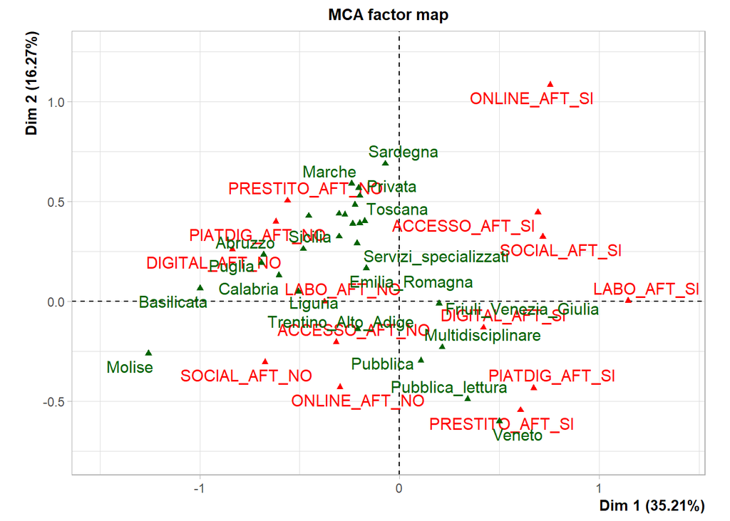

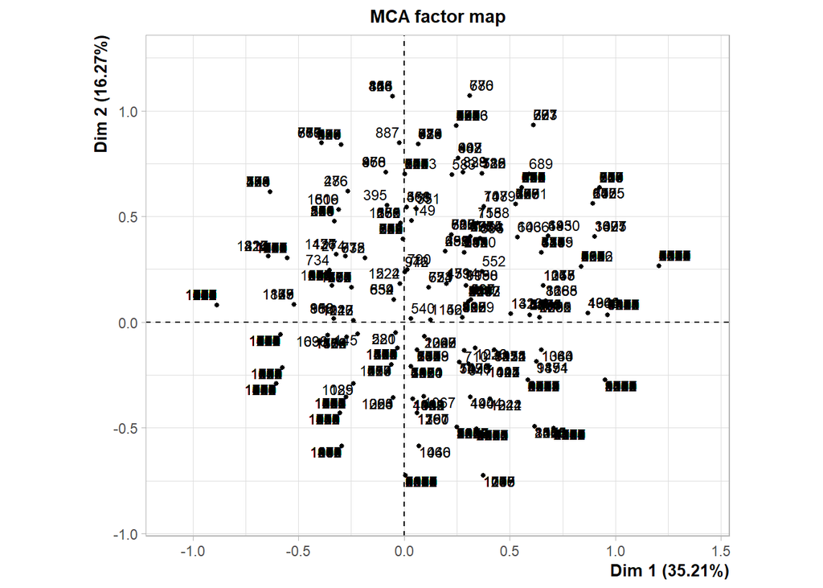

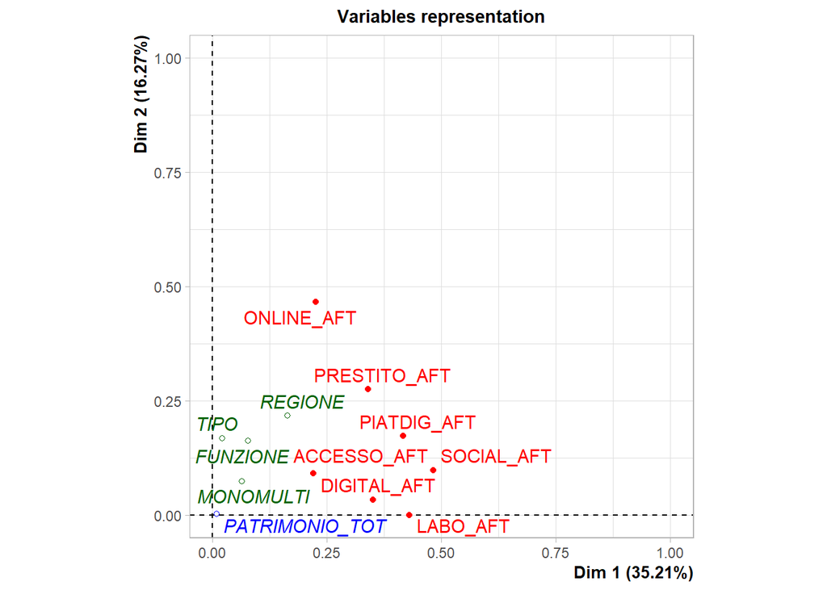

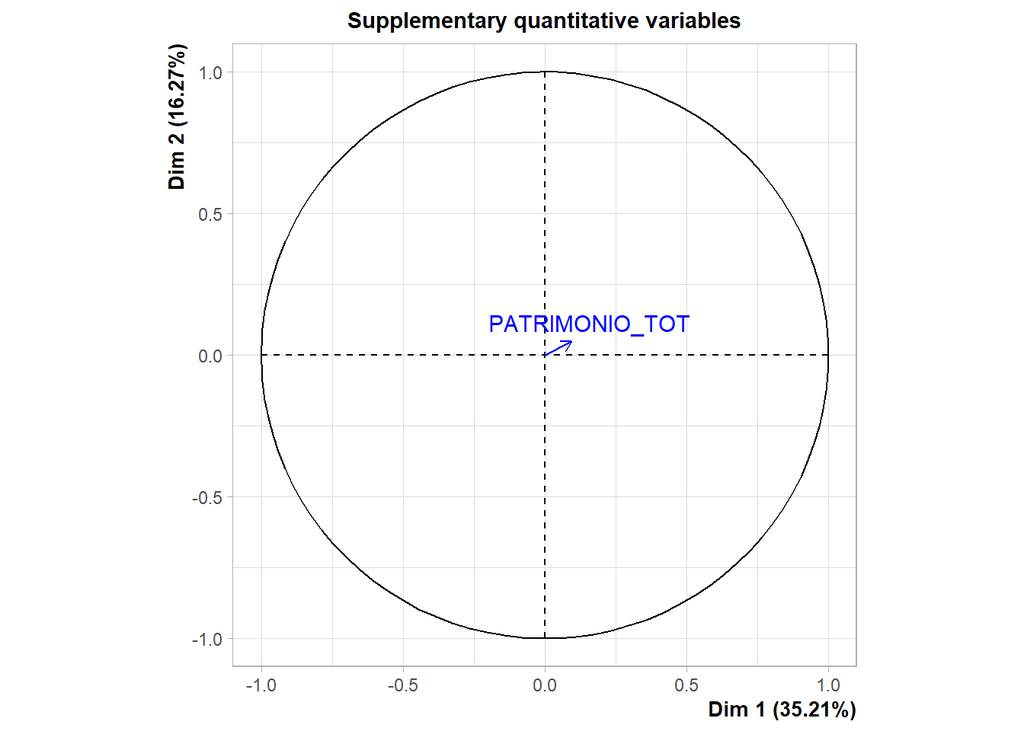

Diamo un’occhiata agli autovalori:

```r
biblio.mca$eig
```

```
##       eigenvalue percentage of variance cumulative percentage of variance
## dim 1 0.35211551              35.211551                          35.21155
## dim 2 0.16270067              16.270067                          51.48162
## dim 3 0.14169974              14.169974                          65.65159
## dim 4 0.09643082               9.643082                          75.29467
## dim 5 0.08860547               8.860547                          84.15522
## dim 6 0.08084036               8.084036                          92.23926
## dim 7 0.07760742               7.760742                         100.00000
```

Vediamo che considerando le prime tre componenti principali abbiamo una varianza spiegata di circa il 66%.

Concentrandoci sui primi due assi principali, vediamo di fornirne un’interpretazione mediante l’ausilio del seguente grafico:

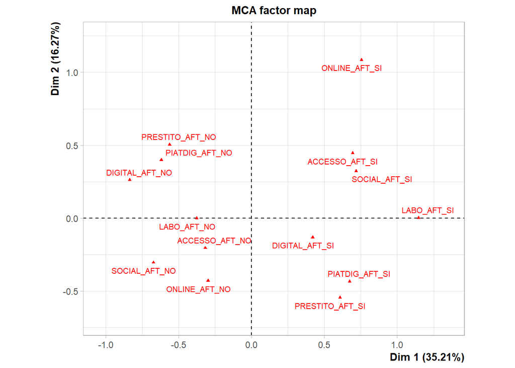

```r
plot.MCA(biblio.mca, invisible = c("ind", "quali.sup"), cex = 0.7)
```

Questo grafico è la rappresentazione delle modalità delle variabili che abbiamo considerato come attive, sul piano costituito dalle prime due componenti principali.

**Analisi della 1° componente principale**: possiamo innanzitutto vedere come esista una netta linea di demarcazione relativa alla presenza (lato destro) e assenza (lato sinistro) dei nuovi servizi post-lockdown. Vista la vicinanza delle modalità *ACCESSO_AFT* e *SOCIAL_AFT*, possiamo supporre che biblioteche che incrementano l’uso dei social media tendano anche ad attivare l’accesso gratuito al materiale digitalizzato, e viceversa. Seguendo lo stesso ragionamento, possiamo supporre che biblioteche che puntano ad una forte presenza on line (tramite conferenze, incontri, etc.) non offrano prestiti in modalità take away. Dalla nuvola di punti vediamo inoltre che le biblioteche che non hanno attivato nuovi servizi sono costituite da una distribuzione più compatta, mentre quelle che hanno provveduto ad attivare nuovi servizi hanno una maggiore variabilità, in quanto la nuvola è più “esplosa”.

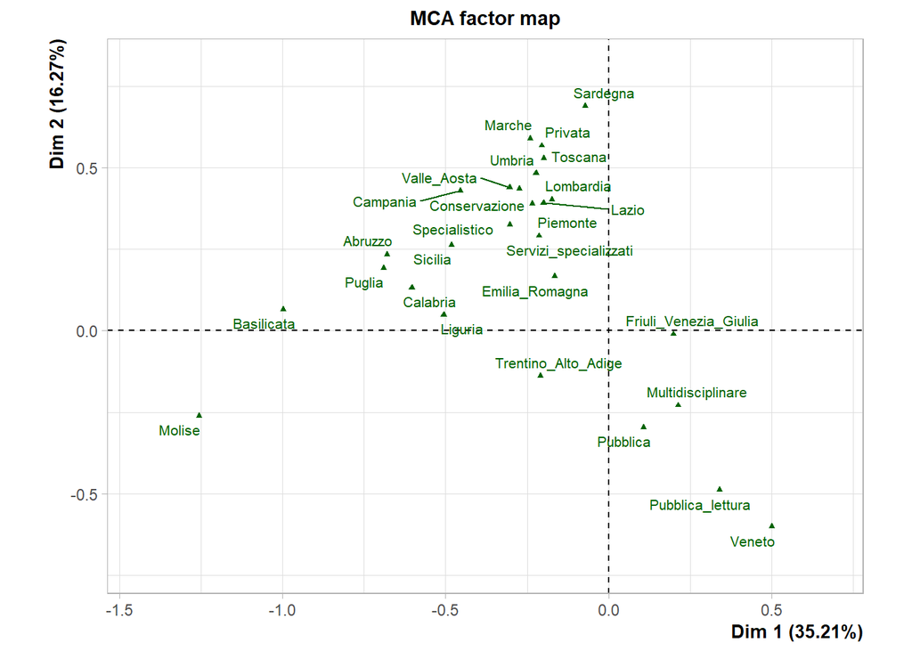

```r
plot.MCA(biblio.mca, invisible = c("ind", "var"), cex = 0.7)
```

Guardando le variabili supplementari, e alla luce di quanto detto per la prima componente, possiamo dire che l’attivazione dei nuovi servizi digitali si è verificata soprattutto nel Nord-Est (Friuli e Veneto), in particolare nelle biblioteche pubbliche.

```r
biblio.mca$var$coord
```

```
##                      Dim 1        Dim 2      Dim 3       Dim 4       Dim 5
## DIGITAL_AFT_NO  -0.8366988  0.262042758  0.6211924  0.86826055 -0.25800735
## DIGITAL_AFT_SI   0.4192014 -0.131288225 -0.3112288 -0.43501445  0.12926641
## PIATDIG_AFT_NO  -0.6192866  0.399813643  0.1488807 -0.22909836  0.26977512
## PIATDIG_AFT_SI   0.6718428 -0.433744080 -0.1615156  0.24854094 -0.29266975
## LABO_AFT_NO     -0.3754546 -0.001121246 -0.2474514 -0.10788287 -0.28252994
## LABO_AFT_SI      1.1449304  0.003419185  0.7545908  0.32898347  0.86156107
## ONLINE_AFT_NO   -0.2985109 -0.429673272 -0.1005919  0.09308790  0.26164077
## ONLINE_AFT_SI    0.7541329  1.085490372  0.2541270 -0.23516943 -0.66098721
## SOCIAL_AFT_NO   -0.6734652 -0.303884976 -0.2332777  0.07861067 -0.08619513
## SOCIAL_AFT_SI    0.7168537  0.323463000  0.2483068 -0.08367522  0.09174832
## ACCESSO_AFT_NO  -0.3173160 -0.204154694  0.4498643 -0.28358000 -0.06427024
## ACCESSO_AFT_SI   0.6928865  0.445789192 -0.9823171  0.61922113  0.14033955
## PRESTITO_AFT_NO -0.5616560  0.505184587 -0.2404777 -0.02739830  0.26302360
## PRESTITO_AFT_SI  0.6060181 -0.545086331  0.2594717  0.02956234 -0.28379838
```

Dalle coordinate dei punti sul piano, troviamo conferma che l’attivazione dei nuovi servizi si trova lungo il semiasse positivo della prima componente principale, mentre la non attivazione di tali servizi sta sul semiasse negativo.

**Analisi della 2° componente principale**: analizzando sia la nuvola dei punti che i contributi possiamo dire che la seconda componente è relativa alla presenza o meno della biblioteca sul web, quindi possiamo interpretarla come una sorta di tasso di “socialità” di quella biblioteca e di conseguenza quanto è attenta a crearsi una fidelizzazione nel pubblico tramite gli eventi. Aiutandoci con le variabili supplementari vediamo difatti che le biblioteche con una maggiore attenzione alla creazione di un’immagine e di un rapporto con il pubblico sono le biblioteche private e specialistiche, collocate perlopiù nel Centro-Nord della penisola. Inoltre, vista la contrapposizione tra le modalità *ONLINE_AFT* e *PRESTITO_AFT*, troviamo conferma del fatto che le biblioteche che sono più attente ad avere una maggiore presenza on line, tendano ad offrire meno prestiti in modalità take away.